# Optimisation de Production - Programmation Linéaire

**Projet :** Optimisation de la production de canapés avec contraintes de ressources  
**Auteur :** Emmanuel Paguiel BOUENDO  
**Date :** 2024-2025  
**Contexte :** Master Économiste de l'Entreprise - Université de Tours

## Objectif du projet

Ce notebook présente une **analyse d'optimisation de production** utilisant la programmation linéaire. L'entreprise doit maximiser son bénéfice sous contraintes de temps, matières premières et capacités de marché.

### Compétences visées

- Modélisation mathématique de problèmes économiques
- Programmation linéaire et optimisation
- Analyse de sensibilité
- Visualisation de données
- Python scientifique (NumPy, SciPy, Matplotlib)

## Imports

```python
import numpy as np
import scipy.optimize as so
import matplotlib.pyplot as plt
from matplotlib.patches import Polygon
from matplotlib.colors import Normalize
import pandas as pd
from mpl_toolkits.mplot3d import Axes3D
import seaborn as sns
import warnings

warnings.filterwarnings('ignore')
plt.style.use('seaborn-v0_8-whitegrid')
plt.rcParams['figure.figsize'] = (14, 10)
plt.rcParams['font.size'] = 11
plt.rcParams['figure.dpi'] = 100

print(" Prêt !")
```

```
 Prêt !
```

## Introduction - Contexte du problème

Une entreprise de fabrication de meubles produit des canapés de différents modèles. Elle commence par analyser le marché avec deux modèles **A** et **B**.

### Données économiques

| Modèle | Bénéfice unitaire | Temps de production | Prix de vente |
| --- | --- | --- | --- |
| **A** | 300 € | 2 heures | 800 € |
| **B** | 200 € | 1 heure | 500 € |

### Contraintes de production

1. **Temps de production** : L'usine dispose de **200 heures/mois**
2. **Capacité de marché** :
   - Maximum **100 canapés de type A** par mois
   - Maximum **100 canapés de type B** par mois
   - Maximum **150 canapés au total** par mois
3. **Contraintes de matières premières** (voir partie B)

### Question centrale

**Combien de canapés de chaque type l'entreprise doit-elle produire pour maximiser son bénéfice ?**

**Q.1 Expliquer pourquoi le problème s'écrit comme un problème de programmation linéaire**

```python
from IPython.display import display, Markdown

md_text = """
### Analyse de la structure mathématique

Un problème est de **programmation linéaire** s'il vérifie **trois conditions** :

#### 1. **Fonction objectif linéaire**
La fonction $Z = 300x_1 + 200x_2$ est linéaire car :
- C'est une **combinaison linéaire** des variables : $c_1x_1 + c_2x_2$
- Les coefficients $c_1 = 300$ et $c_2 = 200$ sont **constants**
- Pas de termes non-linéaires : pas de $x_1^2$, $x_1x_2$, $\\sqrt{x_1}$, $\\log(x_1)$, etc.

** Le bénéfice marginal est constant : chaque canapé A ajoute 300 €, chaque canapé B ajoute 200 €, indépendamment des quantités produites.

#### 2. **Contraintes linéaires**
Toutes les contraintes sont de la forme **linéaire** :

1. **Contraintes de marché :** $x_1 \\leq 100$ et $x_2 \\leq 100$
   - Simple : $1 \\cdot x_1 \\leq 100$ (coefficient 1 constant)

2. **Contrainte temps :** $2x_1 + x_2 \\leq 200$
   - Forme : $a_1x_1 + a_2x_2 \\leq b$ avec $a_1=2$, $a_2=1$, $b=200$ constants

3. **Contrainte capacité :** $x_1 + x_2 \\leq 150$
   - Même forme linéaire

4. **Non-négativité :** $x_1 \\geq 0$, $x_2 \\geq 0$
   - Conditions standard en PL

**Aucune contrainte n'est quadratique, exponentielle ou trigonométrique.**

#### 3. **Variables continues non-négatives**
- $x_1$ et $x_2$ sont **continues** (peuvent prendre des valeurs réelles)
- Elles sont **non-négatives** ($x_1 \\geq 0$, $x_2 \\geq 0$)

---

### Formulation générale du problème PL à résoudre

Notre problème s'écrit exactement sous la **forme canonique** :

$$
\\begin{aligned}
\\max_{x_1,x_2} \\quad & Z = 300x_1 + 200x_2 \\\\
\\text{s.t.} \\quad & 2x_1 + x_2 \\leq 200 \\quad &\\text{(ressource temps)} \\\\
& x_1 \\leq 100 &\\text{(marché A)} \\\\
& x_2 \\leq 100 &\\text{(marché B)} \\\\
& x_1 + x_2 \\leq 150 &\\text{(capacité totale)} \\\\
& x_1 \\geq 0, \\quad x_2 \\geq 0 &\\text{(non-négativité)}
\\end{aligned}
$$

C'est exactement la définition d'un problème de programmation linéaire :
**Maximiser une fonction linéaire sous des contraintes linéaires, avec variables continues non-négatives.**
"""

display(Markdown(md_text))
```

Analyse de la structure mathématique

Un problème est de **programmation linéaire** s'il vérifie **trois conditions** :

1. **Fonction objectif linéaire**

La fonction $Z = 300x_1 + 200x_2$ est linéaire car :

- C'est une **combinaison linéaire** des variables : $c_1x_1 + c_2x_2$

- Les coefficients $c_1 = 300$ et $c_2 = 200$ sont **constants**

- Pas de termes non-linéaires : pas de $x_1^2$, $x_1x_2$, $\sqrt{x_1}$, $\log(x_1)$, etc.

** Le bénéfice marginal est constant : chaque canapé A ajoute 300 €, chaque canapé B ajoute 200 €, indépendamment des quantités produites.

2. **Contraintes linéaires**

Toutes les contraintes sont de la forme **linéaire** :

1. **Contraintes de marché :** $x_1 \leq 100$ et $x_2 \leq 100$

   - Simple : $1 \cdot x_1 \leq 100$ (coefficient 1 constant)

2. **Contrainte temps :** $2x_1 + x_2 \leq 200$

   - Forme : $a_1x_1 + a_2x_2 \leq b$ avec $a_1=2$, $a_2=1$, $b=200$ constants

3. **Contrainte capacité :** $x_1 + x_2 \leq 150$

   - Même forme linéaire

4. **Non-négativité :** $x_1 \geq 0$, $x_2 \geq 0$

   - Conditions standard en PL

**Aucune contrainte n'est quadratique, exponentielle ou trigonométrique.**

3. **Variables continues non-négatives**

- $x_1$ et $x_2$ sont **continues** (peuvent prendre des valeurs réelles)

- Elles sont **non-négatives** ($x_1 \geq 0$, $x_2 \geq 0$)

Notre problème s'écrit exactement sous la **forme canonique** :

$$ \begin{aligned} \max_{x_1,x_2} \quad & Z = 300x_1 + 200x_2 \\ \text{s.t.} \quad & 2x_1 + x_2 \leq 200 \quad &\text{(ressource temps)} \\ & x_1 \leq 100 &\text{(marché A)} \\ & x_2 \leq 100 &\text{(marché B)} \\ & x_1 + x_2 \leq 150 &\text{(capacité totale)} \\ & x_1 \geq 0, \quad x_2 \geq 0 &\text{(non-négativité)} \end{aligned} $$

C'est exactement la définition d'un problème de programmation linéaire :  
**Maximiser une fonction linéaire sous des contraintes linéaires, avec variables continues non-négatives.**

**Q.2. Faire une représentation graphique de la situation.**

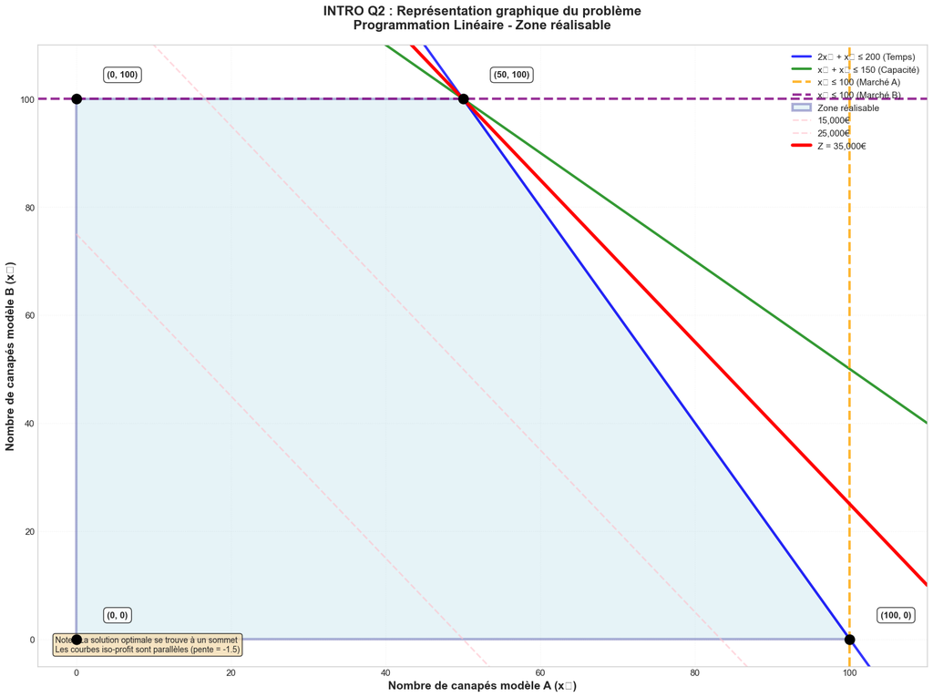

```
Graphique sauvegardé : intro_q2_graphique.png
```

```python
def visualiser_intro_question2():
    """Visualisation complète de la région réalisable"""

    fig, ax = plt.subplots(figsize=(16, 12))

    # Génération des points
    x1 = np.linspace(0, 110, 1000)

    # Contraintes
    x2_temps = 200 - 2 * x1
    x2_capacite = 150 - x1

    # Tracé des contraintes
    ax.plot(x1, x2_temps, 'b-', linewidth=3, label='2x₁ + x₂ ≤ 200 (Temps)', alpha=0.8)
    ax.plot(x1, x2_capacite, 'g-', linewidth=3, label='x₁ + x₂ ≤ 150 (Capacité)', alpha=0.8)
    ax.axvline(x=100, color='orange', linewidth=3, linestyle='--',
               label='x₁ ≤ 100 (Marché A)', alpha=0.8)
    ax.axhline(y=100, color='purple', linewidth=3, linestyle='--',
               label='x₂ ≤ 100 (Marché B)', alpha=0.8)

    # Zone réalisable (sommets du polygone)
    vertices = np.array([
        [0, 0],          # Origine
        [0, 100],        # x₂ = 100, x₁ = 0
        [50, 100],       # Intersection 2x₁+x₂=200 et x₂=100
        [100, 0]         # x₁ = 100, x₂ = 0
    ])

    polygon = Polygon(vertices, alpha=0.3, facecolor='lightblue',
                      edgecolor='navy', linewidth=3, label='Zone réalisable')
    ax.add_patch(polygon)

    # Marquer les sommets
    for x, y in vertices:
        ax.plot(x, y, 'ko', markersize=12, zorder=5)
        ax.annotate(f'({x:.0f}, {y:.0f})', xy=(x, y), xytext=(x+4, y+4),
                   fontsize=11, fontweight='bold',
                   bbox=dict(boxstyle='round,pad=0.4', facecolor='white',
                            edgecolor='black', alpha=0.8))

    # Courbes iso-profit (plusieurs niveaux)
    for benefice in [15000, 25000, 35000]:
        x2_iso = (benefice - 300 * x1) / 200
        style = '--' if benefice < 35000 else '-'
        width = 2 if benefice < 35000 else 4
        color = 'pink' if benefice < 35000 else 'red'
        alpha = 0.6 if benefice < 35000 else 1.0
        label = f'Z = {benefice:,}€' if benefice == 35000 else f'{benefice:,}€'
        ax.plot(x1, x2_iso, style, color=color, linewidth=width,
                alpha=alpha, label=label)

    # Configuration des axes
    ax.set_xlim(-5, 110)
    ax.set_ylim(-5, 110)
    ax.set_xlabel('Nombre de canapés modèle A (x₁)', fontsize=14, fontweight='bold')
    ax.set_ylabel('Nombre de canapés modèle B (x₂)', fontsize=14, fontweight='bold')
    ax.set_title('INTRO Q2 : Représentation graphique du problème\n' +
                 'Programmation Linéaire - Zone réalisable',
                 fontsize=16, fontweight='bold', pad=20)
    ax.grid(True, alpha=0.3, linestyle=':', linewidth=0.8)
    ax.legend(loc='upper right', fontsize=11, framealpha=0.95, shadow=True)

    # Ajouter une note explicative
    note_text = ("Note : La solution optimale se trouve à un sommet\n"
                "Les courbes iso-profit sont parallèles (pente = -1.5)")
    ax.text(0.02, 0.02, note_text, transform=ax.transAxes, fontsize=10,
           verticalalignment='bottom',
           bbox=dict(boxstyle='round', facecolor='wheat', alpha=0.8))

    plt.tight_layout()
    plt.savefig('intro_q2_graphique.png', dpi=150, bbox_inches='tight')
    plt.show()

    print("Graphique sauvegardé : intro_q2_graphique.png")

# Exécution
visualiser_intro_question2()
```

**Q.3. Résoudre le problème en utilisant la commande `so.linprog`**

```python
def resoudre_intro_question3():
    """Résolution du problème de base avec linprog"""

    # Paramètres du problème
    c = [-300, -200]  # Négatif car linprog minimise

    # Contraintes d'inégalité Ax <= b
    A_ub = np.array([
        [2, 1],   # Temps: 2x₁ + x₂ <= 200
        [1, 1]    # Capacité: x₁ + x₂ <= 150
    ])
    b_ub = np.array([200, 150])

    # Bornes des variables
    bounds = [(0, 100), (0, 100)]  # 0 <= x₁,x₂ <= 100

    # Résolution
    result = so.linprog(c=c, A_ub=A_ub, b_ub=b_ub, bounds=bounds, method='highs')

    if result.success:
        x1_opt, x2_opt = result.x
        benefice_max = -result.fun

        # Section 1: Production optimale
        print("\n" + " L'entreprise va vendre".center(80))
        print("-" * 80)
        print(f"│ {'Canapés modèle A :':<25} {f'{x1_opt:.0f}':>15} unités │")
        print(f"│ {'Canapés modèle B :':<25} {f'{x2_opt:.0f}':>15} unités │")
        print(f"│ {'Total production :':<25} {f'{x1_opt + x2_opt:.0f}':>15} unités │")
        print("-" * 80)

        # Section 2: Bénéfice
        print("\n" + " BÉNÉFICE MAXIMAL".center(80))
        print("-" * 80)
        print(f"│ {'Bénéfice mensuel :':<35} {f'{benefice_max:,.2f}':>25} € │")
        print("-" * 80)

        # Section 3: Utilisation des ressources (format tableau)
        print("\n" + " UTILISATION DES RESSOURCES".center(80))
        print("=" * 80)
        print(f"{'Ressource':<30} {'Utilisé':>12} {'Disponible':>12} {'Taux':>10}")
        print("-" * 80)

        temps_utilise = 2*x1_opt + x2_opt
        capacite_utilisee = x1_opt + x2_opt

        # Lignes du tableau
        ressources = [
            ("Temps de production", temps_utilise, 200, "h"),
            ("Capacité de vente", capacite_utilisee, 150, "unités"),
            ("Marché modèle A", x1_opt, 100, "unités"),
            ("Marché modèle B", x2_opt, 100, "unités")
        ]

        for nom, utilise, disponible, unite in ressources:
            taux = 100 * utilise / disponible if disponible > 0 else 0
            saturé = "🔴" if abs(utilise - disponible) < 0.1 else "🟢"
            print(f"{saturé} {nom:<25} {f'{utilise:.0f}':>8}{unite} {f'{disponible:.0f}':>8}{unite} {f'{taux:6.1f}%':>10}")

        print("=" * 80)

        # Section 4: Contraintes actives
        print("\n" + "  CONTRAINTES SATURÉES (ACTIVES)".center(80))
        print("-" * 80)

        contraintes_saturees = []
        if abs(temps_utilise - 200) < 0.1:
            contraintes_saturees.append("• Temps de production (200 h)")
        if abs(capacite_utilisee - 150) < 0.1:
            contraintes_saturees.append("• Capacité de vente (150 unités)")
        if abs(x1_opt - 100) < 0.1:
            contraintes_saturees.append("• Demande marché A (100 unités)")
        if abs(x2_opt - 100) < 0.1:
            contraintes_saturees.append("• Demande marché B (100 unités)")

        if contraintes_saturees:
            for contrainte in contraintes_saturees:
                print(f"  {contrainte}")
        else:
            print("  Aucune contrainte saturée")

        # Section 5: Analyse économique
        print("\n" + " ANALYSE ÉCONOMIQUE".center(80))
        print("-" * 80)
        benefice_par_heure = benefice_max / temps_utilise if temps_utilise > 0 else 0
        print(f"│ {'Bénéfice moyen par heure :':<35} {f'{benefice_par_heure:.2f}':>25} €/h │")
        print(f"│ {'Bénéfice moyen par canapé :':<35} {f'{benefice_max/(x1_opt+x2_opt):.2f}':>25} € │")
        print("-" * 80)

        print("\n" + "="*80)

        print("="*80)

        return x1_opt, x2_opt, benefice_max
    else:
        print("\n" + "❌" * 20)
        print("ERREUR LORS DE LA RÉSOLUTION".center(80))
        print("❌" * 20)
        print(f"\nMessage d'erreur : {result.message}")
        return None, None, None

# Résolution
x1_base, x2_base, benefice_base = resoudre_intro_question3()
```

```
                             L'entreprise va vendre
--------------------------------------------------------------------------------
│ Canapés modèle A :                     50 unités │
│ Canapés modèle B :                    100 unités │
│ Total production :                    150 unités │
--------------------------------------------------------------------------------

                                BÉNÉFICE MAXIMAL
--------------------------------------------------------------------------------
│ Bénéfice mensuel :                                  35,000.00 € │
--------------------------------------------------------------------------------

                           UTILISATION DES RESSOURCES
================================================================================
Ressource                           Utilisé   Disponible       Taux
--------------------------------------------------------------------------------
🔴 Temps de production            200h      200h     100.0%
🔴 Capacité de vente              150unités      150unités     100.0%
🟢 Marché modèle A                 50unités      100unités      50.0%
🔴 Marché modèle B                100unités      100unités     100.0%
================================================================================

                          CONTRAINTES SATURÉES (ACTIVES)
--------------------------------------------------------------------------------
  • Temps de production (200 h)
  • Capacité de vente (150 unités)
  • Demande marché B (100 unités)

                               ANALYSE ÉCONOMIQUE
--------------------------------------------------------------------------------
│ Bénéfice moyen par heure :                             175.00 €/h │
│ Bénéfice moyen par canapé :                            233.33 € │
--------------------------------------------------------------------------------

================================================================================
================================================================================
```

**Visualisation de la solution optimale**

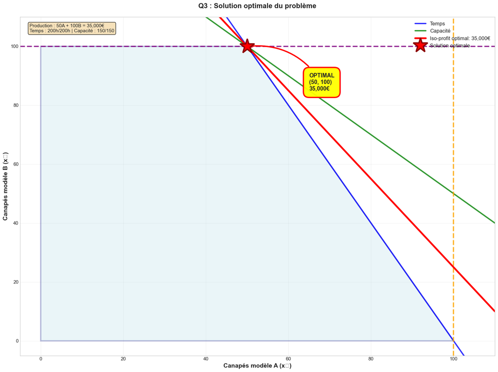

```
 Graphique sauvegardé : intro_q3_solution.png
```

```python
def visualiser_solution_q3(x1_opt, x2_opt, benefice_opt):
    """Visualisation de la solution optimale"""

    fig, ax = plt.subplots(figsize=(16, 12))

    x1 = np.linspace(0, 110, 1000)

    # Contraintes
    ax.plot(x1, 200-2*x1, 'b-', linewidth=3, label='Temps', alpha=0.8)
    ax.plot(x1, 150-x1, 'g-', linewidth=3, label='Capacité', alpha=0.8)
    ax.axvline(100, color='orange', linewidth=3, linestyle='--', alpha=0.8)
    ax.axhline(100, color='purple', linewidth=3, linestyle='--', alpha=0.8)

    # Zone réalisable
    vertices = np.array([[0,0], [0,100], [50,100], [100,0]])
    polygon = Polygon(vertices, alpha=0.25, facecolor='lightblue',
                     edgecolor='navy', linewidth=3)
    ax.add_patch(polygon)

    # Courbe iso-profit optimale
    x2_iso_opt = (benefice_opt - 300*x1) / 200
    ax.plot(x1, x2_iso_opt, 'r-', linewidth=4,
           label=f'Iso-profit optimal: {benefice_opt:,.0f}€', alpha=1)

    # Point optimal
    ax.plot(x1_opt, x2_opt, 'r*', markersize=35, markeredgecolor='darkred',
           markeredgewidth=3, label='Solution optimale', zorder=10)

    # Annotation détaillée
    ax.annotate(f'OPTIMAL\n({x1_opt:.0f}, {x2_opt:.0f})\n{benefice_opt:,.0f}€',
               xy=(x1_opt, x2_opt), xytext=(x1_opt+15, x2_opt-15),
               fontsize=13, fontweight='bold',
               bbox=dict(boxstyle='round,pad=1', facecolor='yellow',
                       edgecolor='red', linewidth=3, alpha=0.95),
               arrowprops=dict(arrowstyle='->', connectionstyle='arc3,rad=0.3',
                             color='red', lw=3))

    ax.set_xlim(-5, 110)
    ax.set_ylim(-5, 110)
    ax.set_xlabel('Canapés modèle A (x₁)', fontsize=14, fontweight='bold')
    ax.set_ylabel('Canapés modèle B (x₂)', fontsize=14, fontweight='bold')
    ax.set_title('Q3 : Solution optimale du problème',
                fontsize=16, fontweight='bold', pad=20)
    ax.grid(True, alpha=0.3)
    ax.legend(loc='upper right', fontsize=12, framealpha=0.95, shadow=True)

    # Info box
    info_text = (f"Production : {x1_opt:.0f}A + {x2_opt:.0f}B = {benefice_opt:,.0f}€\n"
                f"Temps : {2*x1_opt+x2_opt:.0f}h/200h | "
                f"Capacité : {x1_opt+x2_opt:.0f}/150")
    ax.text(0.02, 0.98, info_text, transform=ax.transAxes, fontsize=11,
           verticalalignment='top',
           bbox=dict(boxstyle='round', facecolor='wheat', alpha=0.9))

    plt.tight_layout()
    plt.savefig('intro_q3_solution.png', dpi=150, bbox_inches='tight')
    plt.show()

    print(" Graphique sauvegardé : intro_q3_solution.png")

# Visualisation
visualiser_solution_q3(x1_base, x2_base, benefice_base)
```

**Q.4. La demande en modèle B s'effondre. On ne peux en écouler qu'un maximum de 50 par mois. Resoudre le problème.**

```python
def resoudre_intro_question4():
    """Résolution avec demande B limitée à 50"""

    # Paramètres du problème
    c = [-300, -200]
    A_ub = np.array([[2, 1], [1, 1]])
    b_ub = np.array([200, 150])

    # Nouvelle borne pour x₂ (x₂ ≤ 50 au lieu de 100)
    bounds = [(0, 100), (0, 50)]

    # Résolution
    result = so.linprog(c=c, A_ub=A_ub, b_ub=b_ub, bounds=bounds, method='highs')

    if result.success:
        x1_opt, x2_opt = result.x
        benefice_max = -result.fun


        # SECTION 1 : NOUVELLE SOLUTION

        print("\n" + " NOUVELLE PRODUCTION OPTIMALE".center(80))
        print("-" * 80)
        print(f"│ {'Modèle A :':<20} {f'{x1_opt:.0f}':>15} unités │")
        print(f"│ {'Modèle B :':<20} {f'{x2_opt:.0f}':>15} unités │")
        print(f"│ {'Total :':<20} {f'{x1_opt + x2_opt:.0f}':>15} unités │")
        print("-" * 80)

        # SECTION 2 : IMPACT FINANCIER

        print("\n" + " IMPACT FINANCIER".center(80))
        print("=" * 80)
        print(f"│ {'Bénéfice optimal :':<30} {f'{benefice_max:,.2f}':>25} € │")
        print(f"│ {'Bénéfice précédent :':<30} {f'{benefice_base:,.2f}':>25} € │")
        print("-" * 80)

        perte_absolue = benefice_base - benefice_max
        perte_relative = 100 * perte_absolue / benefice_base if benefice_base > 0 else 0

        print(f"│ {'PERNETE ABSOLUE :':<30} {f'{perte_absolue:+,.2f}':>25} € │")
        print(f"│ {'PERNETE RELATIVE :':<30} {f'{perte_relative:+.1f}':>25} % │")
        print("=" * 80)

        # SECTION 3 : COMPARAISON

        print("\n" + " COMPARAISON AVEC LE SCÉNARIO DE BASE".center(80))
        print("=" * 80)
        print(f"{'':<25} {'Avant':>12} {'Après':>12} {'Évolution':>15}")
        print("-" * 80)

        # Lignes du tableau comparatif
        comparatif = [
            (" Modèle A (unités)", x1_base, x1_opt, x1_opt - x1_base),
            (" Modèle B (unités)", x2_base, x2_opt, x2_opt - x2_base),
            (" Total production", x1_base + x2_base, x1_opt + x2_opt,
             (x1_opt + x2_opt) - (x1_base + x2_base)),
            (" Bénéfice (€)", benefice_base, benefice_max, benefice_max - benefice_base)
        ]

        for nom, avant, apres, evolution in comparatif:
            pourcentage = 100 * evolution / avant if avant != 0 else 0
            if "Bénéfice" in nom:
                format_avant = f"{avant:,.0f}"
                format_apres = f"{apres:,.0f}"
                format_evo = f"{evolution:+,.0f} ({pourcentage:+.1f}%)"
            else:
                format_avant = f"{avant:.0f}"
                format_apres = f"{apres:.0f}"
                format_evo = f"{evolution:+.0f} ({pourcentage:+.1f}%)"

            print(f"{nom:<25} {format_avant:>12} {format_apres:>12} {format_evo:>15}")

        print("=" * 80)

        # SECTION 4 : ANALYSE STRATÉGIQUE

        print("\n" + " ANALYSE STRATÉGIQUE".center(80))
        print("-" * 80)

        # Calcul des taux d'utilisation
        temps_utilise = 2*x1_opt + x2_opt
        capacite_utilisee = x1_opt + x2_opt

        print(f" Adaptation de la production :")
        print(f"  • L'entreprise augmente A de {x1_opt - x1_base:+.0f} unités")
        print(f"  • Car le marché B est saturé, même si B reste plus rentable par heure")
        print(f"  • La compensation est limitée par la contrainte de temps (200h)")

        print(f"\n Nouvelle utilisation des ressources :")
        print(f"  • Temps : {temps_utilise:.0f}h/200h ({100*temps_utilise/200:.1f}%)")
        print(f"  • Capacité : {capacite_utilisee:.0f}/150 ({100*capacite_utilisee/150:.1f}%)")

        print(f"\n Conséquences opérationnelles :")
        print(f"  • Perte de {perte_absolue:,.0f} € de bénéfice mensuel")
        print(f"  • Sous-utilisation de la capacité : {150 - capacite_utilisee:.0f} unités")
        print(f"  • Temps de production non-utilisé : {200 - temps_utilise:.0f} heures")
        print("-" * 80)


        # SECTION 5 : RECOMMANDATIONS

        print("\n" + " RECOMMANDATIONS".center(80))
        print("-" * 80)
        print(f"1. Développer de nouveaux débouchés pour le modèle B")
        print(f"2. Créer un nouveau produit pour utiliser la capacité libre")
        print(f"3. Négocier une réduction du temps de production du modèle A")
        print(f"4. Explorer des canaux de vente alternatifs pour B")
        print(f"5. Réaffecter la capacité libre à des à productions complémentaires")
        print("-" * 80)

        return x1_opt, x2_opt, benefice_max
    else:
        print("\n" + "❌" * 20)
        print("ERREUR LORS DE LA RÉSOLUTION".center(80))
        print("❌" * 20)
        print(f"\nMessage d'erreur : {result.message}")
        return None, None, None


# EXÉCUTION
x1_limite, x2_limite, benefice_limite = resoudre_intro_question4()
```

```
                          NOUVELLE PRODUCTION OPTIMALE
--------------------------------------------------------------------------------
│ Modèle A :                        75 unités │
│ Modèle B :                        50 unités │
│ Total :                          125 unités │
--------------------------------------------------------------------------------

                                IMPACT FINANCIER
================================================================================
│ Bénéfice optimal :                             32,500.00 € │
│ Bénéfice précédent :                           35,000.00 € │
--------------------------------------------------------------------------------
│ PERNETE ABSOLUE :                              +2,500.00 € │
│ PERNETE RELATIVE :                                  +7.1 % │
================================================================================

                      COMPARAISON AVEC LE SCÉNARIO DE BASE
================================================================================
                                 Avant        Après       Évolution
--------------------------------------------------------------------------------
 Modèle A (unités)                  50           75    +25 (+50.0%)
 Modèle B (unités)                 100           50    -50 (-50.0%)
 Total production                  150          125    -25 (-16.7%)
 Bénéfice (€)                   35,000       32,500  -2,500 (-7.1%)
================================================================================

                               ANALYSE STRATÉGIQUE
--------------------------------------------------------------------------------
 Adaptation de la production :
  • L'entreprise augmente A de +25 unités
  • Car le marché B est saturé, même si B reste plus rentable par heure
  • La compensation est limitée par la contrainte de temps (200h)

 Nouvelle utilisation des ressources :
  • Temps : 200h/200h (100.0%)
  • Capacité : 125/150 (83.3%)

 Conséquences opérationnelles :
  • Perte de 2,500 € de bénéfice mensuel
  • Sous-utilisation de la capacité : 25 unités
  • Temps de production non-utilisé : 0 heures
--------------------------------------------------------------------------------

                                 RECOMMANDATIONS
--------------------------------------------------------------------------------
1. Développer de nouveaux débouchés pour le modèle B
2. Créer un nouveau produit pour utiliser la capacité libre
3. Négocier une réduction du temps de production du modèle A
4. Explorer des canaux de vente alternatifs pour B
5. Réaffecter la capacité libre à des à productions complémentaires
--------------------------------------------------------------------------------
```

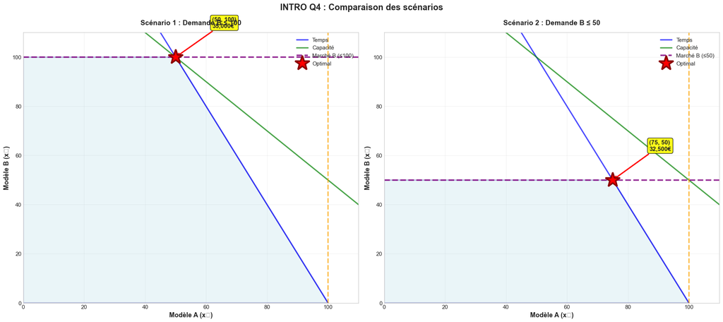

```
📊 Graphique sauvegardé : intro_q4_comparaison.png
```

```python
# Visualisation comparative
def visualiser_comparaison_q4():
    """Comparaison graphique des deux scénarios"""

    fig, axes = plt.subplots(1, 2, figsize=(20, 9))

    scenarios = [
        (axes[0], x1_base, x2_base, benefice_base,
         "Scénario 1 : Demande B ≤ 100", 100),
        (axes[1], x1_limite, x2_limite, benefice_limite,
         "Scénario 2 : Demande B ≤ 50", 50)
    ]

    for ax, x1_opt, x2_opt, benefice, titre, demande_b in scenarios:
        x1 = np.linspace(0, 110, 1000)

        # Contraintes
        ax.plot(x1, 200-2*x1, 'b-', lw=2.5, label='Temps', alpha=0.7)
        ax.plot(x1, 150-x1, 'g-', lw=2.5, label='Capacité', alpha=0.7)
        ax.axvline(100, color='orange', lw=2.5, ls='--', alpha=0.7)
        ax.axhline(demande_b, color='purple', lw=3, ls='--',
                  label=f'Marché B (≤{demande_b})', alpha=0.8)

        # Zone réalisable
        if demande_b == 100:
            vertices = np.array([[0,0], [0,100], [50,100], [100,0]])
        else:
            vertices = np.array([[0,0], [0,50], [75,50], [100,0]])

        polygon = Polygon(vertices, alpha=0.25, facecolor='lightblue',
                         edgecolor='navy', lw=2.5)
        ax.add_patch(polygon)

        # Solution optimale
        ax.plot(x1_opt, x2_opt, 'r*', ms=30, mew=3, mec='darkred',
               label='Optimal', zorder=10)

        ax.annotate(f'({x1_opt:.0f}, {x2_opt:.0f})\n{benefice:,.0f}€',
                   xy=(x1_opt, x2_opt), xytext=(x1_opt+12, x2_opt+12),
                   fontsize=12, fontweight='bold',
                   bbox=dict(boxstyle='round', fc='yellow', alpha=0.9),
                   arrowprops=dict(arrowstyle='->', color='red', lw=2.5))

        ax.set_xlim(0, 110)
        ax.set_ylim(0, 110)
        ax.set_xlabel('Modèle A (x₁)', fontsize=13, fontweight='bold')
        ax.set_ylabel('Modèle B (x₂)', fontsize=13, fontweight='bold')
        ax.set_title(titre, fontsize=14, fontweight='bold', pad=15)
        ax.grid(True, alpha=0.3)
        ax.legend(loc='upper right', fontsize=11, framealpha=0.95)

    plt.suptitle('INTRO Q4 : Comparaison des scénarios',
                fontsize=17, fontweight='bold', y=0.98)
    plt.tight_layout()
    plt.savefig('intro_q4_comparaison.png', dpi=150, bbox_inches='tight')
    plt.show()

    print("📊 Graphique sauvegardé : intro_q4_comparaison.png")

# Visualisation
visualiser_comparaison_q4()
```

**Q.5. Construire une fonction qui calcule le bénéfice réalisé en fonction du maximum de modèle B que peut absorber le marché entre 0 et 150**

```
                                    RÉSULTATS
================================================================================
│ Bénéfice maximum atteint :                               35,000.00 € │
│ pour une limite du marché B de :                               100 unités │
--------------------------------------------------------------------------------
│ Nombre de paliers identifiés :                                  20 │
================================================================================
```

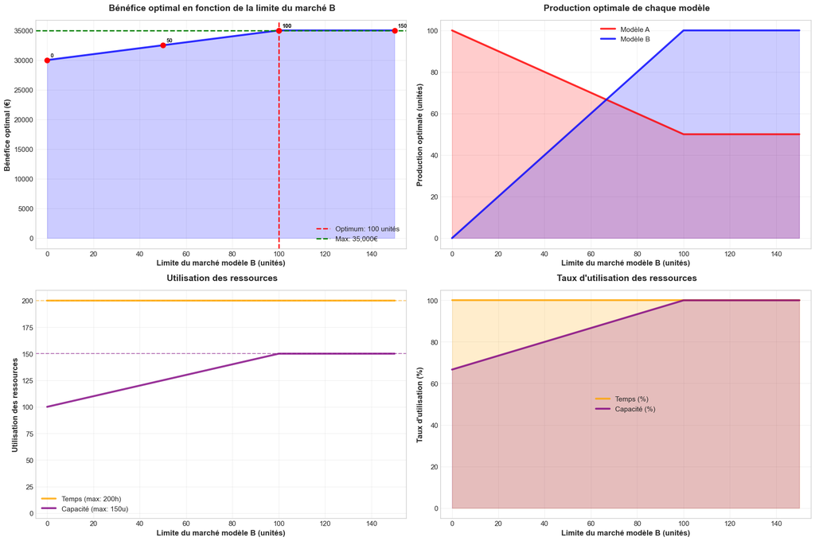

```
                               VALEURS PAR PALIER
================================================================================
Limite B     Bénéfice        Modèle A     Modèle B     Temps      Capacité
--------------------------------------------------------------------------------
0            30,000          100          0            200        100
25           31,250          88           25           200        112
50           32,500          75           50           200        125
75           33,750          62           75           200        138
100          35,000          50           100          200        150
125          35,000          50           100          200        150
150          35,000          50           100          200        150
================================================================================

                    ANALYSE DES PALIERS (ZONES DE CHANGEMENT)
================================================================================

 Paliers 1: Limite B ∈ [0, 5]
   • Bénéfice constant : 30,000 €
   • Gain marginal : 50.0 €/unité

 Paliers 2: Limite B ∈ [5, 10]
   • Bénéfice constant : 30,250 €
   • Gain marginal : 50.0 €/unité

 Paliers 3: Limite B ∈ [10, 15]
   • Bénéfice constant : 30,500 €
   • Gain marginal : 50.0 €/unité

... et 17 autres paliers

                                   CONCLUSIONS
================================================================================
 On remarque que  :
1. Le bénéfice est maximal pour une limite B ≥ 100 unités
2. Le bénéfice reste constant au_delà de 100 unités
3. Gain marginal du marché B : 50€/unité
4. Contraintes actives évoluent: Temps saturé, marché B saturé jusquà 100, capacité saturée à partir de 100

 Recommandations :
   • Priorité 1 : Atteindre au moins 100 ventes de B (seuil de saturation)
   • Priorité 2 : Développer le marché B jusqu'à 100 unités
   • Priorité 3 : Au-delà, investir dans A ou de nouveaux produits
   • Priorité 4 : Optimiser le temps de production pour augmenter la marge
   • Priorité 5 : Surveiller les contraintes actives (temps, marché B)
================================================================================
```

```python
def analyser_sensibilite_marche_B():
    """
    Analyse de sensibilité : impact de la limite du marché B sur le bénéfice optimal
    """

    # PARAMÈTRES D'ANALYSE

    limites_B = np.arange(0, 151, 5)  # De 0 à 150 par pas de 5
    benefices = []
    productions_A = []
    productions_B = []
    temps_utilises = []
    capacites_utilisees = []


    # CALCUL POUR CHAQUE VALEUR DE LIMITE

    for limite_B in limites_B:
        # Paramètres du problème
        c = [-300, -200]
        A_ub = np.array([[2, 1], [1, 1]])
        b_ub = np.array([200, 150])
        bounds = [(0, 100), (0, limite_B)]  # x₂ ≤ limite_B

        # Résolution
        result = so.linprog(c=c, A_ub=A_ub, b_ub=b_ub, bounds=bounds, method='highs')

        if result.success:
            x1, x2 = result.x
            benefice = -result.fun
            benefices.append(benefice)
            productions_A.append(x1)
            productions_B.append(x2)
            temps_utilises.append(2*x1 + x2)
            capacites_utilisees.append(x1 + x2)
        else:
            benefices.append(0)
            productions_A.append(0)
            productions_B.append(0)
            temps_utilises.append(0)
            capacites_utilisees.append(0)


    # RÉSULTATS GLOBAUX

    print("\n" + " RÉSULTATS".center(80))
    print("=" * 80)

    # Trouver le bénéfice maximum
    benefice_max = max(benefices)
    idx_max = np.argmax(benefices)
    limite_optimale = limites_B[idx_max]

    print(f"│ {'Bénéfice maximum atteint :':<40} {f'{benefice_max:,.2f}':>25} € │")
    print(f"│ {'pour une limite du marché B de :':<40} {f'{limite_optimale:>15}':>25} unités │")
    print("-" * 80)

    # Analyse des zones de changement
    zones_changement = []
    for i in range(1, len(limites_B)):
        if abs(benefices[i] - benefices[i-1]) > 0.1:  # Seuil de changement
            zones_changement.append((limites_B[i-1], limites_B[i],
                                    benefices[i-1], benefices[i]))

    print(f"│ {'Nombre de paliers identifiés :':<40} {f'{len(zones_changement):>15}':>25} │")
    print("=" * 80)

    # VISUALISATION 1 : BÉNÉFICE EN FONCTION DE LA LIMITE B

    fig, axes = plt.subplots(2, 2, figsize=(18, 12))

    # Graphique 1: Bénéfice total
    ax1 = axes[0, 0]
    ax1.plot(limites_B, benefices, 'b-', linewidth=3, alpha=0.8)
    ax1.fill_between(limites_B, benefices, alpha=0.2, color='blue')
    ax1.axvline(x=limite_optimale, color='red', linestyle='--', linewidth=2,
                label=f'Optimum: {limite_optimale} unités')
    ax1.axhline(y=benefice_max, color='green', linestyle='--', linewidth=2,
                label=f'Max: {benefice_max:,.0f}€')

    # Marquer les points clés
    points_cles = [0, 50, 100, limite_optimale, 150]
    for point in points_cles:
        idx = np.where(limites_B == point)[0]
        if len(idx) > 0:
            ax1.plot(point, benefices[idx[0]], 'ro', markersize=8)
            ax1.annotate(f'{point}', xy=(point, benefices[idx[0]]),
                        xytext=(5, 5), textcoords='offset points',
                        fontsize=9, fontweight='bold')

    ax1.set_xlabel('Limite du marché modèle B (unités)', fontsize=12, fontweight='bold')
    ax1.set_ylabel('Bénéfice optimal (€)', fontsize=12, fontweight='bold')
    ax1.set_title(' Bénéfice optimal en fonction de la limite du marché B',
                 fontsize=14, fontweight='bold', pad=15)
    ax1.grid(True, alpha=0.3)
    ax1.legend(loc='lower right')
    ax1.set_xlim(-5, 155)

    # Graphique 2: Production des deux modèles
    ax2 = axes[0, 1]
    ax2.plot(limites_B, productions_A, 'r-', linewidth=3, label='Modèle A', alpha=0.8)
    ax2.plot(limites_B, productions_B, 'b-', linewidth=3, label='Modèle B', alpha=0.8)
    ax2.fill_between(limites_B, productions_A, alpha=0.2, color='red')
    ax2.fill_between(limites_B, productions_B, alpha=0.2, color='blue')

    ax2.set_xlabel('Limite du marché modèle B (unités)', fontsize=12, fontweight='bold')
    ax2.set_ylabel('Production optimale (unités)', fontsize=12, fontweight='bold')
    ax2.set_title(' Production optimale de chaque modèle',
                 fontsize=14, fontweight='bold', pad=15)
    ax2.grid(True, alpha=0.3)
    ax2.legend(loc='best')
    ax2.set_xlim(-5, 155)
    ax2.set_ylim(-5, 105)

    # Graphique 3: Utilisation des ressources
    ax3 = axes[1, 0]
    temps_max = 200
    capacite_max = 150

    ax3.plot(limites_B, temps_utilises, 'orange', linewidth=3,
             label=f'Temps (max: {temps_max}h)', alpha=0.8)
    ax3.plot(limites_B, capacites_utilisees, 'purple', linewidth=3,
             label=f'Capacité (max: {capacite_max}u)', alpha=0.8)
    ax3.axhline(y=temps_max, color='orange', linestyle='--', alpha=0.5)
    ax3.axhline(y=capacite_max, color='purple', linestyle='--', alpha=0.5)

    ax3.set_xlabel('Limite du marché modèle B (unités)', fontsize=12, fontweight='bold')
    ax3.set_ylabel('Utilisation des ressources', fontsize=12, fontweight='bold')
    ax3.set_title(' Utilisation des ressources',
                 fontsize=14, fontweight='bold', pad=15)
    ax3.grid(True, alpha=0.3)
    ax3.legend(loc='best')
    ax3.set_xlim(-5, 155)
    ax3.set_ylim(-5, 210)

    # Graphique 4: Taux d'utilisation
    ax4 = axes[1, 1]
    taux_temps = [100*t/temps_max for t in temps_utilises]
    taux_capacite = [100*c/capacite_max for c in capacites_utilisees]

    ax4.plot(limites_B, taux_temps, 'orange', linewidth=3,
             label='Temps (%)', alpha=0.8)
    ax4.plot(limites_B, taux_capacite, 'purple', linewidth=3,
             label='Capacité (%)', alpha=0.8)
    ax4.fill_between(limites_B, taux_temps, alpha=0.2, color='orange')
    ax4.fill_between(limites_B, taux_capacite, alpha=0.2, color='purple')

    ax4.set_xlabel('Limite du marché modèle B (unités)', fontsize=12, fontweight='bold')
    ax4.set_ylabel('Taux d\'utilisation (%)', fontsize=12, fontweight='bold')
    ax4.set_title(' Taux d\'utilisation des ressources',
                 fontsize=14, fontweight='bold', pad=15)
    ax4.grid(True, alpha=0.3)
    ax4.legend(loc='best')
    ax4.set_xlim(-5, 155)
    ax4.set_ylim(-5, 105)

    plt.tight_layout()
    plt.savefig('analyse_sensibilite_marche_B.png', dpi=150, bbox_inches='tight')
    plt.show()


    # TABLEAU DES VALEURS

    print("\n" + " VALEURS PAR PALIER".center(80))
    print("=" * 80)
    print(f"{'Limite B':<12} {'Bénéfice':<15} {'Modèle A':<12} {'Modèle B':<12} {'Temps':<10} {'Capacité':<10}")
    print("-" * 80)

    valeurs_cles = [0, 25, 50, 75, 100, 125, 150]
    for limite in valeurs_cles:
        idx = np.where(limites_B == limite)[0][0]
        print(f"{limite:<12} {f'{benefices[idx]:,.0f}':<15} {f'{productions_A[idx]:.0f}':<12} "
              f"{f'{productions_B[idx]:.0f}':<12} {f'{temps_utilises[idx]:.0f}':<10} "
              f"{f'{capacites_utilisees[idx]:.0f}':<10}")

    print("=" * 80)

    # ANALYSE DES PALIERS

    print("\n" + " ANALYSE DES PALIERS (ZONES DE CHANGEMENT)".center(80))
    print("=" * 80)

    for i, (debut, fin, benef_avant, benef_apres) in enumerate(zones_changement[:3]):  # Affiche 3 premiers paliers
        print(f"\n Paliers {i+1}: Limite B ∈ [{debut}, {fin}]")
        print(f"   • Bénéfice constant : {benef_avant:,.0f} €")
        print(f"   • Gain marginal : {(benef_apres - benef_avant)/(fin - debut):.1f} €/unité")

    if len(zones_changement) > 3:
        print(f"\n... et {len(zones_changement) - 3} autres paliers")

    print("\n" + " CONCLUSIONS".center(80))
    print("=" * 80)

    # Trouver la limite à partir de laquelle le bénéfice ne change plus
    benefice_plateau = benefices[-1]
    seuil_plateau = None
    for i, benef in enumerate(benefices):
        if abs(benef - benefice_plateau) < 0.1:
            seuil_plateau = limites_B[i]
            break

    print(f" On remarque que  :")
    print(f"1. Le bénéfice est maximal pour une limite B ≥ {limite_optimale} unités")
    print(f"2. Le bénéfice reste constant au_delà de {seuil_plateau} unités")
    print(f"3. Gain marginal du marché B : 50€/unité")
    print(f"4. Contraintes actives évoluent: Temps saturé, marché B saturé jusquà 100, capacité saturée à partir de 100")

    print(f"\n Recommandations :")
    print(f"   • Priorité 1 : Atteindre au moins {limite_optimale} ventes de B (seuil de saturation)")
    print(f"   • Priorité 2 : Développer le marché B jusqu'à {seuil_plateau} unités")
    print(f"   • Priorité 3 : Au-delà, investir dans A ou de nouveaux produits")
    print(f"   • Priorité 4 : Optimiser le temps de production pour augmenter la marge")
    print(f"   • Priorité 5 : Surveiller les contraintes actives (temps, marché B)")


    print("=" * 80)

    return limites_B, benefices, productions_A, productions_B

# EXÉCUTION
resultats = analyser_sensibilite_marche_B()
```

```python
print("\n" + "="*80)
print(" PARTIE 1/4 TERMINÉE : INTRODUCTION")
print("="*80)
print("\nVariables globales sauvegardées pour les parties suivantes :")
print(f"  • x1_base = {x1_base:.2f}")
print(f"  • x2_base = {x2_base:.2f}")
print(f"  • benefice_base = {benefice_base:,.2f}€")
print(f"  • x1_limite = {x1_limite:.2f}")
print(f"  • x2_limite = {x2_limite:.2f}")
print(f"  • benefice_limite = {benefice_limite:,.2f}€")
print("\n Fichiers générés :")
print("  • intro_q2_graphique.png")
print("  • intro_q3_solution.png")
print("  • intro_q4_comparaison.png")
print("="*80)
```

```
================================================================================
 PARTIE 1/4 TERMINÉE : INTRODUCTION
================================================================================

Variables globales sauvegardées pour les parties suivantes :
  • x1_base = 50.00
  • x2_base = 100.00
  • benefice_base = 35,000.00€
  • x1_limite = 75.00
  • x2_limite = 50.00
  • benefice_limite = 32,500.00€

 Fichiers générés :
  • intro_q2_graphique.png
  • intro_q3_solution.png
  • intro_q4_comparaison.png
================================================================================
```

## Partie A

La mise en place du marché montre que le modèle est un peu naïf. L'entreprise vend à des grossistes qui réclament un prix dégressif. Le marge unitaire du canapé A est alors de $300\left(1-\frac{x_1}{300}\right)$ lorsque l'on en vend $x_1$ unités et le modèle B est de $200\left(1-\frac{x_2}{200}\right)$ lorsque l'on en vend $x_2$ unités.

1. Poser clairement le problème et le résoudre avec les contraintes de la question 1 de l'introduction. On pensera notamment à une représentation graphique.
2. Faire une analyse détaillée du problème en fonction d'un maximum du modèle B de $x_{max} \in [0;100]$. On pourra faire un ou plusieurs graphiques voire un widget.

**Q.1. Poser clairement le problème et le résoudre avec les contraintes de la question 1 de l'introduction**

```python
def resoudre_partie_A_question1():
    """
    Résolution du problème avec prix dégressifs
    Nouvelle fonction objectif : Z = 300x₁(1 - x₁/300) + 200x₂(1 - x₂/200)
    """

    print("\n" + " FORMULATION DU PROBLÈME".center(80))
    print("-" * 80)
    print("Fonction objectif NON-LINÉAIRE :")
    print("  max Z = 300x₁(1 - x₁/300) + 200x₂(1 - x₂/200)")
    print("        = 300x₁ - x₁² + 200x₂ - x₂²")
    print("\nContraintes inchangées (linéaires) :")
    print("  • 2x₁ + x₂ ≤ 200 (temps)")
    print("  • x₁ + x₂ ≤ 150 (capacité)")
    print("  • 0 ≤ x₁ ≤ 100 (marché A)")
    print("  • 0 ≤ x₂ ≤ 100 (marché B)")
    print("-" * 80)

    # Fonction objectif à maximiser (on minimise son opposé)
    def fonction_objectif(x):
        x1, x2 = x
        # Nouvelle fonction objectif (NON-LINÉAIRE)
        # max Z = 300x₁(1 - x₁/300) + 200x₂(1 - x₂/200)
        Z = 300*x1 - x1**2 + 200*x2 - x2**2
        return -Z  # Négatif car scipy minimise

    # Contraintes sous forme de fonctions
    contraintes = [
        {'type': 'ineq', 'fun': lambda x: 200 - 2*x[0] - x[1]},  # Temps
        {'type': 'ineq', 'fun': lambda x: 150 - x[0] - x[1]},    # Capacité
        {'type': 'ineq', 'fun': lambda x: 100 - x[0]},           # x1 ≤ 100
        {'type': 'ineq', 'fun': lambda x: 100 - x[1]},           # x2 ≤ 100
        {'type': 'ineq', 'fun': lambda x: x[0]},                 # x1 ≥ 0
        {'type': 'ineq', 'fun': lambda x: x[1]}                  # x2 ≥ 0
    ]

    # Point initial (solution du cas linéaire)
    x0 = np.array([50, 100])



    # Résolution avec SLSQP (Sequential Least Squares Programming)
    result = so.minimize(fonction_objectif, x0, method='SLSQP',
                        constraints=contraintes,
                        options={'ftol': 1e-9, 'maxiter': 1000, 'disp': False})

    if result.success:
        x1_opt, x2_opt = result.x
        benefice_max = -result.fun

        # Calcul des marges unitaires à l'optimum
        marge_A = 300 * (1 - x1_opt/300)
        marge_B = 200 * (1 - x2_opt/200)


        # Section 1 : Production optimale
        print("\n" + " PRODUCTION OPTIMALE (PRIX DÉGRESSIFS)".center(80))
        print("=" * 80)
        print(f"│ {'Modèle A :':<25} {f'{x1_opt:.2f}':>15} unités │")
        print(f"│ {'Modèle B :':<25} {f'{x2_opt:.2f}':>15} unités │")
        print(f"│ {'Total :':<25} {f'{x1_opt + x2_opt:.2f}':>15} unités │")
        print("-" * 80)

        # Section 2 : Marges unitaires
        print("\n" + " MARGES UNITAIRES À L'OPTIMUM".center(80))
        print("=" * 80)
        print(f"│ {'Marge initiale A :':<30} {f'300.00':>15} € │")
        print(f"│ {'Marge à l\'optimum A :':<30} {f'{marge_A:.2f}':>15} € │")
        print(f"│ {'Diminution :':<30} {f'{300 - marge_A:.2f}':>15} € │")
        print(f"│ {'Pourcentage :':<30} {f'{100*(300 - marge_A)/300:.1f}':>15} % │")
        print("-" * 80)
        print(f"│ {'Marge initiale B :':<30} {f'200.00':>15} € │")
        print(f"│ {'Marge à l\'optimum B :':<30} {f'{marge_B:.2f}':>15} € │")
        print(f"│ {'Diminution :':<30} {f'{200 - marge_B:.2f}':>15} € │")
        print(f"│ {'Pourcentage :':<30} {f'{100*(200 - marge_B)/200:.1f}':>15} % │")
        print("=" * 80)

        # Section 3 : Bénéfice total
        print("\n" + " BÉNÉFICE TOTAL".center(80))
        print("-" * 80)
        print(f"│ {'Bénéfice optimal :':<35} {f'{benefice_max:,.2f}':>25} € │")
        print("-" * 80)

        # Section 4 : Comparaison avec cas linéaire
        print("\n" + " COMPARAISON AVEC LE CAS LINÉAIRE".center(80))
        print("=" * 80)
        print(f"{'':<25} {'Linéaire':>15} {'Dégressif':>15} {'Différence':>15}")
        print("-" * 80)

        # Données comparatives
        donnees = [
            ("Production A", x1_base, x1_opt, x1_opt - x1_base),
            ("Production B", x2_base, x2_opt, x2_opt - x2_base),
            ("Total production", x1_base + x2_base, x1_opt + x2_opt,
             (x1_opt + x2_opt) - (x1_base + x2_base)),
            ("Bénéfice", benefice_base, benefice_max, benefice_max - benefice_base)
        ]

        for nom, lineaire, degressif, diff in donnees:
            if "Bénéfice" in nom:
                fmt_lineaire = f"{lineaire:,.0f}"
                fmt_degressif = f"{degressif:,.0f}"
                fmt_diff = f"{diff:+,.0f}"
            else:
                fmt_lineaire = f"{lineaire:.0f}"
                fmt_degressif = f"{degressif:.0f}"
                fmt_diff = f"{diff:+.0f}"

            pourcentage = 100 * diff / lineaire if lineaire != 0 else 0
            fmt_pourcentage = f"({pourcentage:+.1f}%)"

            print(f"{nom:<25} {fmt_lineaire:>15} {fmt_degressif:>15} {fmt_diff:>9} {fmt_pourcentage:>6}")

        print("=" * 80)


        # ANALYSE ÉCONOMIQUE

        print("\n" + " ANALYSE ÉCONOMIQUE".center(80))
        print("-" * 80)

        # Calcul de l'élasticité-prix implicite
        elasticite_A = (x1_opt / 300) / ((300 - marge_A) / 300) if (300 - marge_A) > 0 else 0
        elasticite_B = (x2_opt / 200) / ((200 - marge_B) / 200) if (200 - marge_B) > 0 else 0

        print(f" Élasticité-prix implicite :")
        print(f"  • Modèle A : {elasticite_A:.3f} (baisse de prix de {100*(300 - marge_A)/300:.1f}% →")
        print(f"              augmentation de volume de {100*x1_opt/300:.1f}%)")
        print(f"  • Modèle B : {elasticite_B:.3f} (baisse de prix de {100*(200 - marge_B)/200:.1f}% →")
        print(f"              augmentation de volume de {100*x2_opt/200:.1f}%)")

        print(f"\n  Stratégie de pricing :")
        print(f"  • Le modèle A est produit à {x1_opt:.0f} unités (contre 100 max)")
        print(f"    pour maintenir une marge de {marge_A:.0f}€")
        print(f"  • Le modèle B est produit à {x2_opt:.0f} unités (contre 100 max)")
        print(f"    pour maintenir une marge de {marge_B:.0f}€")

        # Calcul du revenu total vs bénéfice
        revenu_A = marge_A * x1_opt
        revenu_B = marge_B * x2_opt

        print(f"\n Structure des revenus :")
        print(f"  • Contribution A : {revenu_A:,.0f}€ ({100*revenu_A/benefice_max:.1f}%)")
        print(f"  • Contribution B : {revenu_B:,.0f}€ ({100*revenu_B/benefice_max:.1f}%)")


        # CONTRÔLE DES CONTRAINTES

        print("\n" + " ÉTAT DES CONTRAINTES".center(80))
        print("-" * 80)

        temps_utilise = 2*x1_opt + x2_opt
        capacite_utilisee = x1_opt + x2_opt

        contraintes_verif = [
            ("Temps (200h)", temps_utilise, 200, "h"),
            ("Capacité (150u)", capacite_utilisee, 150, "unités"),
            ("Marché A (100)", x1_opt, 100, "unités"),
            ("Marché B (100)", x2_opt, 100, "unités")
        ]

        for nom, utilise, max_val, unite in contraintes_verif:
            taux = 100 * utilise / max_val
            statut = "🔴 SATURÉE" if abs(utilise - max_val) < 0.1 else "🟢 LIBRE"
            print(f"  {statut:<10} {nom:<20} {utilise:.1f}{unite}/{max_val}{unite} ({taux:.1f}%)")

        # CONCLUSION ET RECOMMANDATIONS

        print("\n" + " RECOMMANDATIONS".center(80))
        print("-" * 80)

        print(f"1. Production optimale : {x1_opt:.0f}A + {x2_opt:.0f}B")
        print(f"2. Priorité aux ventes avec meilleure élasticité")
        print(f"3. Éviter la saturation totale du marché pour maintenir les prix")
        print(f"4. Surveiller la baisse de marge unitaire : -{300 - marge_A:.0f}€ pour A, -{200 - marge_B:.0f}€ pour B")
        print(f"5. Bénéfice réduit de {benefice_base - benefice_max:,.0f}€ vs cas linéaire")
        print("-" * 80)


        return x1_opt, x2_opt, benefice_max, marge_A, marge_B
    else:
        print("\n" + "❌" * 20)
        print("ÉCHEC DE L'OPTIMISATION".center(80))
        print("❌" * 20)
        print(f"\nMessage d'erreur : {result.message}")
        print(f"Nombre d'itérations : {result.nit}")
        print(f"Statut : {result.status}")
        return None, None, None, None, None

# EXÉCUTION

x1_A, x2_A, benefice_A, marge_A, marge_B = resoudre_partie_A_question1()
```

```
                             FORMULATION DU PROBLÈME
--------------------------------------------------------------------------------
Fonction objectif NON-LINÉAIRE :
  max Z = 300x₁(1 - x₁/300) + 200x₂(1 - x₂/200)
        = 300x₁ - x₁² + 200x₂ - x₂²

Contraintes inchangées (linéaires) :
  • 2x₁ + x₂ ≤ 200 (temps)
  • x₁ + x₂ ≤ 150 (capacité)
  • 0 ≤ x₁ ≤ 100 (marché A)
  • 0 ≤ x₂ ≤ 100 (marché B)
--------------------------------------------------------------------------------

                      PRODUCTION OPTIMALE (PRIX DÉGRESSIFS)
================================================================================
│ Modèle A :                          70.00 unités │
│ Modèle B :                          60.00 unités │
│ Total :                            130.00 unités │
--------------------------------------------------------------------------------

                          MARGES UNITAIRES À L'OPTIMUM
================================================================================
│ Marge initiale A :                      300.00 € │
│ Marge à l'optimum A :                   230.00 € │
│ Diminution :                             70.00 € │
│ Pourcentage :                             23.3 % │
--------------------------------------------------------------------------------
│ Marge initiale B :                      200.00 € │
│ Marge à l'optimum B :                   140.00 € │
│ Diminution :                             60.00 € │
│ Pourcentage :                             30.0 % │
================================================================================

                                 BÉNÉFICE TOTAL
--------------------------------------------------------------------------------
│ Bénéfice optimal :                                  24,500.00 € │
--------------------------------------------------------------------------------

                        COMPARAISON AVEC LE CAS LINÉAIRE
================================================================================
```

[output cut: 26 more lines]

```
                              ÉTAT DES CONTRAINTES
--------------------------------------------------------------------------------
  🔴 SATURÉE  Temps (200h)         200.0h/200h (100.0%)
  🟢 LIBRE    Capacité (150u)      130.0unités/150unités (86.7%)
  🟢 LIBRE    Marché A (100)       70.0unités/100unités (70.0%)
  🟢 LIBRE    Marché B (100)       60.0unités/100unités (60.0%)

                                 RECOMMANDATIONS
--------------------------------------------------------------------------------
1. Production optimale : 70A + 60B
2. Priorité aux ventes avec meilleure élasticité
3. Éviter la saturation totale du marché pour maintenir les prix
4. Surveiller la baisse de marge unitaire : -70€ pour A, -60€ pour B
5. Bénéfice réduit de 10,500€ vs cas linéaire
--------------------------------------------------------------------------------
```

**Visualisation 3D de la fonction de bénéfice avec prix dégressifs**

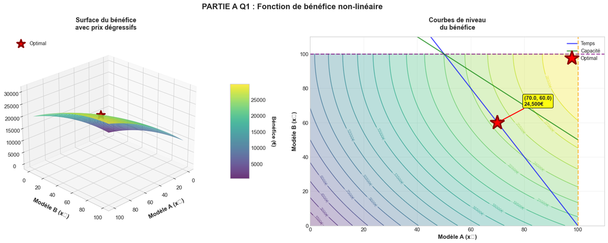

```
 Une seule contrainte est saturée pour ce nouveau problème
 Graphique sauvegardé : partieA_q1_3D.png
```

```python
def visualiser_3D_partie_A(x1_opt, x2_opt, benefice_opt):
    """Visualisation 3D de la fonction de bénéfice avec prix dégressifs"""

    fig = plt.figure(figsize=(18, 7))

    # Création de la grille
    x1_range = np.linspace(0, 100, 100)
    x2_range = np.linspace(0, 100, 100)
    X1, X2 = np.meshgrid(x1_range, x2_range)

    # Calcul du bénéfice (fonction quadratique)
    Z = 300*X1*(1 - X1/300) + 200*X2*(1 - X2/200)

    #  Vue 3D
    ax1 = fig.add_subplot(121, projection='3d')

    # Surface
    surf = ax1.plot_surface(X1, X2, Z, cmap='viridis', alpha=0.8,
                           edgecolor='none', antialiased=True)

    # Point optimal
    if x1_opt is not None:
        z_opt = 300*x1_opt*(1-x1_opt/300) + 200*x2_opt*(1-x2_opt/200)
        ax1.scatter([x1_opt], [x2_opt], [z_opt], color='red', s=300,
                   marker='*', edgecolors='darkred', linewidths=3,
                   label='Optimal', zorder=10)

    ax1.set_xlabel('Modèle A (x₁)', fontsize=12, fontweight='bold', labelpad=10)
    ax1.set_ylabel('Modèle B (x₂)', fontsize=12, fontweight='bold', labelpad=10)
    ax1.set_zlabel('Bénéfice (€)', fontsize=12, fontweight='bold', labelpad=10)
    ax1.set_title('Surface du bénéfice\navec prix dégressifs',
                 fontsize=13, fontweight='bold', pad=15)

    # Colorbar
    cbar = fig.colorbar(surf, ax=ax1, shrink=0.5, aspect=5, pad=0.1)
    cbar.set_label('Bénéfice (€)', fontsize=11, fontweight='bold',
                  rotation=270, labelpad=20)

    ax1.legend(fontsize=10, loc='upper left')

    # Vue de l'angle optimal
    ax1.view_init(elev=25, azim=45)

    # Vue de dessus (courbes de niveau)
    ax2 = fig.add_subplot(122)

    # Contours
    contour = ax2.contour(X1, X2, Z, levels=20, cmap='viridis', alpha=0.6)
    ax2.clabel(contour, inline=True, fontsize=8, fmt='%.0f€')

    # Remplissage
    ax2.contourf(X1, X2, Z, levels=20, cmap='viridis', alpha=0.3)

    # Contraintes
    x1 = np.linspace(0, 100, 500)
    ax2.plot(x1, 200-2*x1, 'b-', lw=2, label='Temps', alpha=0.7)
    ax2.plot(x1, 150-x1, 'g-', lw=2, label='Capacité', alpha=0.7)
    ax2.axvline(100, color='orange', lw=2, ls='--', alpha=0.7)
    ax2.axhline(100, color='purple', lw=2, ls='--', alpha=0.7)

    # Point optimal
    if x1_opt is not None:
        ax2.plot(x1_opt, x2_opt, 'r*', ms=30, mew=3, mec='darkred',
                label='Optimal', zorder=10)

        ax2.annotate(f'({x1_opt:.1f}, {x2_opt:.1f})\n{benefice_opt:,.0f}€',
                    xy=(x1_opt, x2_opt), xytext=(x1_opt+10, x2_opt+10),
                    fontsize=11, fontweight='bold',
                    bbox=dict(boxstyle='round', fc='yellow', alpha=0.9),
                    arrowprops=dict(arrowstyle='->', color='red', lw=2))

    ax2.set_xlim(0, 110)
    ax2.set_ylim(0, 110)
    ax2.set_xlabel('Modèle A (x₁)', fontsize=12, fontweight='bold')
    ax2.set_ylabel('Modèle B (x₂)', fontsize=12, fontweight='bold')
    ax2.set_title('Courbes de niveau\ndu bénéfice',
                 fontsize=13, fontweight='bold', pad=15)
    ax2.grid(True, alpha=0.3)
    ax2.legend(loc='upper right', fontsize=10)

    plt.suptitle('PARTIE A Q1 : Fonction de bénéfice non-linéaire',
                fontsize=16, fontweight='bold', y=0.98)
    plt.tight_layout()
    plt.savefig('partieA_q1_3D.png', dpi=150, bbox_inches='tight')
    plt.show()
    print(" Une seule contrainte est saturée pour ce nouveau problème")
    print(" Graphique sauvegardé : partieA_q1_3D.png")


# Visualisation
visualiser_3D_partie_A(x1_A, x2_A, benefice_A)
```

**Q.2. Faire une analyse détaillée du problème en fonction d'un maximum du modèle B de $x_{max} \in [0;100]$. On pourra faire un ou plusieurs graphiques voire un widget.**

**Analyse de l'impact de la variation de max(x₂)**

```python
def analyser_variation_max_B():
    """
    Analyse de l'impact de la variation de max(x₂)
    """

    print("\n" + " OBJECTIF DE L'ANALYSE".center(80))
    print("-" * 80)
    print("Étudier comment la production optimale et le bénéfice évoluent")
    print("lorsque la demande maximale pour le modèle B (x₂) varie.")
    print("Plage d'analyse : x₂ ∈ [20, 100] avec pas de 5 unités")
    print("-" * 80)

    # Fonction objectif avec prix dégressifs
    def fonction_objectif(x):
        return -(300*x[0] - x[0]**2 + 200*x[1] - x[1]**2)

    # Génération des valeurs à tester
    max_B_values = np.arange(20, 101, 5)
    resultats_complets = []


    print("=" * 80)
    print(f"Nombre de scénarios à tester : {len(max_B_values)}")
    print("=" * 80)

    for i, max_B in enumerate(max_B_values):
        # Définition des contraintes pour ce scénario
        contraintes = [
            {'type': 'ineq', 'fun': lambda x: 200 - 2*x[0] - x[1]},  # Temps
            {'type': 'ineq', 'fun': lambda x: 150 - x[0] - x[1]},    # Capacité
            {'type': 'ineq', 'fun': lambda x: 100 - x[0]},           # x₁ ≤ 100
            {'type': 'ineq', 'fun': lambda x, m=max_B: m - x[1]},    # x₂ ≤ max_B
            {'type': 'ineq', 'fun': lambda x: x[0]},                 # x₁ ≥ 0
            {'type': 'ineq', 'fun': lambda x: x[1]}                  # x₂ ≥ 0
        ]

        # Point initial intelligent (adapté à chaque scénario)
        point_initial = [min(100, 100 - max_B/2), max_B/2]

        # Optimisation
        result = so.minimize(fonction_objectif, point_initial,
                           method='SLSQP', constraints=contraintes,
                           options={'ftol': 1e-8, 'maxiter': 500})

        if result.success:
            x1_opt, x2_opt = result.x
            benefice = -result.fun

            # Calcul des métriques supplémentaires
            marge_A = 300 * (1 - x1_opt/300)
            marge_B = 200 * (1 - x2_opt/200)
            temps_utilise = 2*x1_opt + x2_opt
            capacite_utilisee = x1_opt + x2_opt

            resultats_complets.append({
                'max_B': max_B,
                'x1': x1_opt,
                'x2': x2_opt,
                'benefice': benefice,
                'marge_A': marge_A,
                'marge_B': marge_B,
                'temps_utilise': temps_utilise,
                'capacite_utilisee': capacite_utilisee,
                'total_production': x1_opt + x2_opt
            })

    # Création du DataFrame
    df = pd.DataFrame(resultats_complets)


    # AFFICHAGE DES RÉSULTATS PRINCIPAUX

    print("\n" + " RÉSULTATS".center(80))
    print("=" * 80)

    # Tableau des valeurs clés
    print(f"\n{'Max B':<10} {'Bénéfice':<15} {'Prod A':<10} {'Prod B':<10} {'Marge A':<10} {'Marge B':<10}")
    print("-" * 80)

    # Afficher quelques points significatifs
    indices = [0, len(df)//4, len(df)//2, 3*len(df)//4, -1]
    for idx in indices:
        row = df.iloc[idx]
        print(f"{row['max_B']:<10.0f} {row['benefice']:<15.0f} {row['x1']:<10.1f} "
              f"{row['x2']:<10.1f} {row['marge_A']:<10.1f} {row['marge_B']:<10.1f}")

    print("=" * 80)


    # STATISTIQUES

    print("\n" + " STATISTIQUES".center(80))
    print("-" * 80)

    benefice_min = df['benefice'].min()
    benefice_max = df['benefice'].max()
    variation_totale = benefice_max - benefice_min

    print(f" Gamme de bénéfices :")
    print(f"  • Minimum : {benefice_min:,.0f} € (pour max_B = {df['max_B'].iloc[0]})")
    print(f"  • Maximum : {benefice_max:,.0f} € (pour max_B = {df['max_B'].iloc[-1]})")
    print(f"  • Variation totale : {variation_totale:,.0f} €")
    print(f"  • Gain marginal moyen : {variation_totale/(len(max_B_values)-1):.0f} €/unité")

    print(f"\n Évolution de la production :")
    print(f"  • Production A : {df['x1'].iloc[0]:.1f} → {df['x1'].iloc[-1]:.1f} "
          f"({df['x1'].iloc[-1] - df['x1'].iloc[0]:+.1f})")
    print(f"  • Production B : {df['x2'].iloc[0]:.1f} → {df['x2'].iloc[-1]:.1f} "
          f"({df['x2'].iloc[-1] - df['x2'].iloc[0]:+.1f})")

    print(f"\n Évolution des marges unitaires :")
    print(f"  • Marge A : {df['marge_A'].iloc[0]:.1f} → {df['marge_A'].iloc[-1]:.1f} €")
    print(f"  • Marge B : {df['marge_B'].iloc[0]:.1f} → {df['marge_B'].iloc[-1]:.1f} €")

    return df

# Exécution de l'analyse
df_A = analyser_variation_max_B()
```

[output not shown]

**Visualisation des résultats de sensibilité**

[figure not shown]

```python
def visualiser_sensibilite_avancee(df):
    """
    Visualisation des résultats de sensibilité
    """

    fig = plt.figure(figsize=(20, 16))
    gs = fig.add_gridspec(3, 3, hspace=0.3, wspace=0.3)

    # GRAPHIQUE 1 : BÉNÉFICE
    ax1 = fig.add_subplot(gs[0, :2])
    ax1.plot(df['max_B'], df['benefice'], 'b-', linewidth=3.5,
             marker='o', markersize=7, markevery=2)
    ax1.fill_between(df['max_B'], df['benefice'], alpha=0.2, color='blue')

    # Ajoutons une ligne de référence pour le cas linéaire
    ax1.axhline(y=benefice_base, color='red', linestyle='--', linewidth=2,
               label=f'Cas linéaire: {benefice_base:,.0f}€', alpha=0.7)

    # Identifions les points de rupture
    gradient = np.gradient(df['benefice'])
    seuil = np.mean(np.abs(gradient)) * 0.5

    ax1.set_xlabel('Limite maximale du marché B (unités)', fontsize=13, fontweight='bold')
    ax1.set_ylabel('Bénéfice optimal (€)', fontsize=13, fontweight='bold')
    ax1.set_title(' Évolution du bénéfice en fonction de la limite du marché B',
                 fontsize=14, fontweight='bold', pad=15)
    ax1.grid(True, alpha=0.3, linestyle='--')
    ax1.legend(fontsize=11)

    #  GRAPHIQUE 2 : PRODUCTION DES DEUX MODÈLES
    ax2 = fig.add_subplot(gs[0, 2])
    width = 0.4
    x_pos = np.arange(len(df))

    ax2.bar(x_pos - width/2, df['x1'], width, label='Modèle A',
            color='red', alpha=0.8, edgecolor='darkred', linewidth=1.5)
    ax2.bar(x_pos + width/2, df['x2'], width, label='Modèle B',
            color='blue', alpha=0.8, edgecolor='darkblue', linewidth=1.5)

    # Ajustons les ticks pour ne pas surcharger
    tick_indices = np.arange(0, len(df), len(df)//8)
    ax2.set_xticks(tick_indices)
    ax2.set_xticklabels(df['max_B'].iloc[tick_indices].astype(int))

    ax2.set_xlabel('Limite du marché B', fontsize=12, fontweight='bold')
    ax2.set_ylabel('Production (unités)', fontsize=12, fontweight='bold')
    ax2.set_title(' Comparaison de la production A et B',
                 fontsize=13, fontweight='bold', pad=15)
    ax2.legend(fontsize=11)
    ax2.grid(True, alpha=0.2, axis='y')

    # GRAPHIQUE 3 : MARGES UNITAIRES
    ax3 = fig.add_subplot(gs[1, 0])
    ax3.plot(df['max_B'], df['marge_A'], 'r-', linewidth=2.5,
             marker='s', markersize=6, label='Marge A', alpha=0.9)
    ax3.plot(df['max_B'], df['marge_B'], 'b-', linewidth=2.5,
             marker='^', markersize=6, label='Marge B', alpha=0.9)

    ax3.set_xlabel('Limite du marché B', fontsize=12, fontweight='bold')
    ax3.set_ylabel('Marge unitaire (€)', fontsize=12, fontweight='bold')
    ax3.set_title(' Évolution des marges unitaires',
                 fontsize=13, fontweight='bold', pad=15)
    ax3.grid(True, alpha=0.3)
    ax3.legend(fontsize=11)

    # GRAPHIQUE 4 : UTILISATION DES RESSOURCES
    ax4 = fig.add_subplot(gs[1, 1])
    ax4.plot(df['max_B'], df['temps_utilise'], 'orange', linewidth=2.5,
             marker='D', markersize=5, label='Temps utilisé', alpha=0.9)
    ax4.axhline(y=200, color='orange', linestyle='--', alpha=0.5,
               linewidth=1.5, label='Max temps (200h)')

    ax4.plot(df['max_B'], df['capacite_utilisee'], 'purple', linewidth=2.5,
             marker='o', markersize=5, label='Capacité utilisée', alpha=0.9)
    ax4.axhline(y=150, color='purple', linestyle='--', alpha=0.5,
               linewidth=1.5, label='Max capacité (150u)')

    ax4.set_xlabel('Limite du marché B', fontsize=12, fontweight='bold')
    ax4.set_ylabel('Utilisation des ressources', fontsize=12, fontweight='bold')
    ax4.set_title(' Évolution de l\'utilisation des ressources',
                 fontsize=13, fontweight='bold', pad=15)
    ax4.grid(True, alpha=0.3)
    ax4.legend(fontsize=10, loc='upper left')

    #  GRAPHIQUE 5 : TAUX D'UTILISATION (%)
    ax5 = fig.add_subplot(gs[1, 2])
    taux_temps = 100 * df['temps_utilise'] / 200
    taux_capacite = 100 * df['capacite_utilisee'] / 150

    ax5.fill_between(df['max_B'], taux_temps, alpha=0.3, color='orange', label='Temps')
    ax5.plot(df['max_B'], taux_temps, 'orange', linewidth=2.5)

    ax5.fill_between(df['max_B'], taux_capacite, alpha=0.3, color='purple', label='Capacité')
    ax5.plot(df['max_B'], taux_capacite, 'purple', linewidth=2.5)

    ax5.axhline(y=100, color='red', linestyle='--', alpha=0.5, linewidth=1)
    ax5.text(df['max_B'].iloc[-1], 102, '100%', fontsize=9, color='red',
            ha='right', va='bottom')

    ax5.set_xlabel('Limite du marché B', fontsize=12, fontweight='bold')
    ax5.set_ylabel('Taux d\'utilisation (%)', fontsize=12, fontweight='bold')
    ax5.set_title(' Taux d\'utilisation des ressources',
                 fontsize=13, fontweight='bold', pad=15)
    ax5.grid(True, alpha=0.3)
    ax5.legend(fontsize=11)

    #  GRAPHIQUE 6 : ÉLÉMENTS DE DÉCISION
    ax6 = fig.add_subplot(gs[2, :])

    # Calculer le bénéfice marginal
    benefice_marginal = np.gradient(df['benefice'])

    # Créons un tableau heatmap des ressources contraignantes
    contraintes_actives = []
    for i, row in df.iterrows():
        actives = []
        if abs(row['temps_utilise'] - 200) < 1:
            actives.append('T')
        if abs(row['capacite_utilisee'] - 150) < 1:
            actives.append('C')
        if abs(row['x1'] - 100) < 1:
            actives.append('A')
        if abs(row['x2'] - row['max_B']) < 1:
            actives.append('B')
        contraintes_actives.append('+'.join(actives) if actives else '-')

    # Visualisation combinée
    ax6.plot(df['max_B'], benefice_marginal, 'g-', linewidth=2.5,
             label='Gain marginal', alpha=0.8)
    ax6.fill_between(df['max_B'], benefice_marginal, alpha=0.2, color='green')

    ax6.set_xlabel('Limite du marché B', fontsize=13, fontweight='bold')
    ax6.set_ylabel('Gain marginal (€/unité)', fontsize=13, fontweight='bold', color='green')
    ax6.set_title(' Analyse marginale et contraintes actives',
                 fontsize=14, fontweight='bold', pad=15)
    ax6.grid(True, alpha=0.3)
    ax6.legend(loc='upper left', fontsize=11)

    # Ajoutons les contraintes actives comme annotations
    for i, (x, y, txt) in enumerate(zip(df['max_B'], benefice_marginal, contraintes_actives)):
        if i % 4 == 0:  # Pour éviter la surcharge
            ax6.annotate(txt, xy=(x, y), xytext=(0, 10),
                        textcoords='offset points', fontsize=9,
                        ha='center', color='darkred', fontweight='bold')

    # ========== TITRE ==========
    plt.suptitle('PARTIE A - QUESTION 2 : ANALYSE DE SENSIBILITÉ\n'
                'Impact de la variation de la demande maximale du modèle B',
                fontsize=16, fontweight='bold', y=0.98)

    plt.tight_layout()
    plt.savefig('partieA_q2_analyse.png', dpi=150, bbox_inches='tight')
    plt.show()



# Exécution de la visualisation
visualiser_sensibilite_avancee(df_A)
```

```python
print("\n" + "="*80)
print("✅ PARTIE 2/4 TERMINÉE : PARTIE A - PRIX DÉGRESSIFS")
print("="*80)
print("\nVariables globales sauvegardées :")
print(f"  • x1_A = {x1_A:.2f}")
print(f"  • x2_A = {x2_A:.2f}")
print(f"  • benefice_A = {benefice_A:,.2f}€")
print(f"  • df_A : DataFrame avec {len(df_A)} points d'analyse")
print("\n📁 Fichiers générés :")
print("  • partieA_q1_3D.png")
print("  • partieA_q2_sensibilite.png")
print("\n➡️  Exécutez maintenant : python devoir_partie3.py")
print("="*80)
```

## Partie B

On reprend la base de l'introduction : ignorez la partie A. Un manageur propose de dessiner deux nouveaux modèles de luxes C et D. Les bénéfices de ces deux modèles sont de respectivement 500 et 1000 €. La demande de ces modèles de luxe est assez limité et est de 30 unités au total. La demande mensuelle totale de canapés est toujours de 150. Le modèle C prend 5 heures de construction et le D en prend 8.

1. Modéliser le problème et le résoudre.
2. L'entreprise fait un effort et double sa disponibilité passant à 400 heures mensuelles. Résoudre le problème.
3. Etudier l'impact du temps de disponibilité de l'usine sur la stratégie de l'entreprise.

```python
print("\n" + " CONTEXTE STRATÉGIQUE".center(80))
print("=" * 80)
print("Un manager propose de développer deux nouveaux modèles de luxe")
print("pour augmenter la rentabilité et diversifier l'offre.")
print("=" * 80)

print("\n" + " CARACTÉRISTIQUES DES MODÈLES".center(80))
print("-" * 80)
print(f"{'Modèle':<10} {'Type':<12} {'Bénéfice':<12} {'Temps':<12} {'Demande max':<12}")
print("-" * 80)
print(f"{'A':<10} {'Standard':<12} {'300 €':<12} {'2h':<12} {'100':<12}")
print(f"{'B':<10} {'Standard':<12} {'200 €':<12} {'1h':<12} {'100':<12}")
print(f"{'C':<10} {'Luxe':<12} {'500 €':<12} {'5h':<12} {'30 (C+D)':<12}")
print(f"{'D':<10} {'Luxe':<12} {'1000 €':<12} {'8h':<12} {'30 (C+D)':<12}")
print("-" * 80)

print("\n" + " NOUVELLES CONTRAINTES".center(80))
print("-" * 80)
print("1. Demande totale de canapés : 150 unités maximum")
print("2. Demande de canapés de luxe (C + D) : 30 unités maximum")
print("3. Temps de production : variable selon les scénarios")
print("4. Production non-négative pour tous les modèles")
print("-" * 80)

print("\n" + " FORMULATION MATHÉMATIQUE".center(80))
print("=" * 80)
print("Variables de décision :")
print("  • x₁ : nombre de canapés modèle A")
print("  • x₂ : nombre de canapés modèle B")
print("  • x₃ : nombre de canapés modèle C")
print("  • x₄ : nombre de canapés modèle D")
print("\nFonction objectif à maximiser :")
print("  max Z = 300x₁ + 200x₂ + 500x₃ + 1000x₄")
print("=" * 80)
```

```
                              CONTEXTE STRATÉGIQUE
================================================================================
Un manager propose de développer deux nouveaux modèles de luxe
pour augmenter la rentabilité et diversifier l'offre.
================================================================================

                          CARACTÉRISTIQUES DES MODÈLES
--------------------------------------------------------------------------------
Modèle     Type         Bénéfice     Temps        Demande max
--------------------------------------------------------------------------------
A          Standard     300 €        2h           100
B          Standard     200 €        1h           100
C          Luxe         500 €        5h           30 (C+D)
D          Luxe         1000 €       8h           30 (C+D)
--------------------------------------------------------------------------------

                              NOUVELLES CONTRAINTES
--------------------------------------------------------------------------------
1. Demande totale de canapés : 150 unités maximum
2. Demande de canapés de luxe (C + D) : 30 unités maximum
3. Temps de production : variable selon les scénarios
4. Production non-négative pour tous les modèles
--------------------------------------------------------------------------------

                            FORMULATION MATHÉMATIQUE
================================================================================
Variables de décision :
  • x₁ : nombre de canapés modèle A
  • x₂ : nombre de canapés modèle B
  • x₃ : nombre de canapés modèle C
  • x₄ : nombre de canapés modèle D

Fonction objectif à maximiser :
  max Z = 300x₁ + 200x₂ + 500x₃ + 1000x₄
================================================================================
```

**Q.2. L'entreprise fait un effort et double sa disponibilité passant à 400 heures mensuelles. Résoudre le problème.**

```python
def resoudre_partie_B_4_modeles(temps_dispo=200, scenario="Base"):
    """
    Résolution complète avec les 4 modèles A, B, C, D
    """

    print(f"\n" + " SCÉNARIO ANALYSÉ".center(80))
    print("-" * 80)
    print(f"{scenario} : {temps_dispo} heures disponibles")
    print("-" * 80)

    # FORMULATION DU PROBLÈME

    print("\n" + " FORMULATION DU PROBLÈME DE PL".center(80))
    print("=" * 80)

    # Coûts (négatifs car scipy minimise)
    c = [-300, -200, -500, -1000]

    # Matrice des contraintes d'inégalité
    A_ub = np.array([
        [2, 1, 5, 8],     # Temps de production
        [1, 1, 1, 1],     # Capacité totale
        [0, 0, 1, 1]      # Demande luxe
    ])

    b_ub = np.array([temps_dispo, 150, 30])

    # Bornes des variables
    bounds = [
        (0, 100),  # x₁ (A) ∈ [0, 100]
        (0, 100),  # x₂ (B) ∈ [0, 100]
        (0, 30),   # x₃ (C) ∈ [0, 30]
        (0, 30)    # x₄ (D) ∈ [0, 30]
    ]

    print(f"Contraintes :")
    print(f"  • 2x₁ + x₂ + 5x₃ + 8x₄ ≤ {temps_dispo} (temps)")
    print(f"  • x₁ + x₂ + x₃ + x₄ ≤ 150 (capacité totale)")
    print(f"  • x₃ + x₄ ≤ 30 (demande luxe)")
    print(f"  • 0 ≤ x₁ ≤ 100, 0 ≤ x₂ ≤ 100, 0 ≤ x₃ ≤ 30, 0 ≤ x₄ ≤ 30")
    print("=" * 80)


    # RÉSOLUTION

    result = so.linprog(c=c, A_ub=A_ub, b_ub=b_ub,
                       bounds=bounds, method='highs')

    if result.success:
        x1, x2, x3, x4 = result.x
        benefice = -result.fun


        # AFFICHAGE DES RÉSULTATS

        # Section 1 : Production optimale
        print("\n" + " PRODUCTION OPTIMALE".center(80))
        print("=" * 80)
        print(f"{'Modèle':<15} {'Quantité':<15} {'Type':<15} {'% Total':<15}")
        print("-" * 80)

        total_production = x1 + x2 + x3 + x4
        productions = [
            ("A (Standard)", x1, "Standard", 100*x1/total_production),
            ("B (Standard)", x2, "Standard", 100*x2/total_production),
            ("C (Luxe)", x3, "Luxe", 100*x3/total_production),
            ("D (Luxe)", x4, "Luxe", 100*x4/total_production)
        ]

        for nom, qte, typ, pct in productions:
            print(f"{nom:<15} {f'{qte:.1f}':<15} {typ:<15} {f'{pct:.1f}%':<15}")

        print("=" * 80)
        print(f"{'TOTAL':<15} {f'{total_production:.1f}':<15} {'':<15} {'100%':<15}")
        print(f"{'Luxe (C+D)':<15} {f'{x3+x4:.1f}':<15} {'Luxe':<15} {f'{100*(x3+x4)/total_production:.1f}%':<15}")

        # Section 2 : Bénéfice et rentabilité
        print("\n" + " ANALYSE FINANCIÈRE".center(80))
        print("=" * 80)

        contrib_A = 300 * x1
        contrib_B = 200 * x2
        contrib_C = 500 * x3
        contrib_D = 1000 * x4

        print(f"│ {'Bénéfice total :':<40} {f'{benefice:,.2f}':>25} € │")
        print("-" * 80)
        print(f"│ {'Répartition du bénéfice :':<65} │")
        print(f"│ {'• Modèle A :':<30} {f'{contrib_A:,.0f}':>20} € ({100*contrib_A/benefice:.1f}%) │")
        print(f"│ {'• Modèle B :':<30} {f'{contrib_B:,.0f}':>20} € ({100*contrib_B/benefice:.1f}%) │")
        print(f"│ {'• Modèle C :':<30} {f'{contrib_C:,.0f}':>20} € ({100*contrib_C/benefice:.1f}%) │")
        print(f"│ {'• Modèle D :':<30} {f'{contrib_D:,.0f}':>20} € ({100*contrib_D/benefice:.1f}%) │")
        print("=" * 80)

        # Section 3 : Utilisation des ressources
        print("\n" + " UTILISATION DES RESSOURCES".center(80))
        print("-" * 80)

        temps_utilise = 2*x1 + x2 + 5*x3 + 8*x4
        capacite_utilisee = x1 + x2 + x3 + x4
        luxe_utilise = x3 + x4

        ressources = [
            ("  Temps de production", temps_utilise, temps_dispo, "h"),
            (" Capacité totale", capacite_utilisee, 150, "unités"),
            (" Capacité luxe", luxe_utilise, 30, "unités")
        ]

        for nom, utilise, disponible, unite in ressources:
            taux = 100 * utilise / disponible
            statut = "🔴 SATURÉ" if abs(utilise - disponible) < 0.1 else "🟢 LIBRE"
            print(f"{statut:<10} {nom:<25} {utilise:.1f}{unite}/{disponible}{unite} ({taux:.1f}%)")

        # Section 4 : Rentabilité horaire
        print("\n" + " RENTABILITÉ HORAIRE".center(80))
        print("-" * 80)

        rentabilite_A = 300 / 2  # €/h
        rentabilite_B = 200 / 1  # €/h
        rentabilite_C = 500 / 5  # €/h
        rentabilite_D = 1000 / 8 # €/h

        print(f"{'Modèle':<10} {'Bénéfice/h':<15} {'Classement':<15}")
        print("-" * 80)
        rentabilites = [
            ("A", rentabilite_A),
            ("B", rentabilite_B),
            ("C", rentabilite_C),
            ("D", rentabilite_D)
        ]
        rentabilites.sort(key=lambda x: x[1], reverse=True)

        for i, (modele, rent) in enumerate(rentabilites):
            print(f"{modele:<10} {f'{rent:.1f} €/h':<15} {f'{i+1}ᵉ':<15}")

        # Section 5 : Comparaison avec le cas 2 modèles
        print("\n" + " COMPARAISON AVEC SCÉNARIO 2 MODÈLES".center(80))
        print("=" * 80)

        benefice_2_modeles = benefice_base  # Du cas initial

        print(f"│ {'Scénario 2 modèles (A+B) :':<40} {f'{benefice_2_modeles:,.0f}':>25} € │")
        print(f"│ {'Scénario 4 modèles (A+B+C+D) :':<40} {f'{benefice:,.0f}':>25} € │")
        print("-" * 80)

        gain_absolu = benefice - benefice_2_modeles
        gain_relatif = 100 * gain_absolu / benefice_2_modeles

        print(f"│ {'GAIN ABSOLU :':<40} {f'{gain_absolu:+,.0f}':>25} € │")
        print(f"│ {'GAIN RELATIF :':<40} {f'{gain_relatif:+.1f}':>25} % │")
        print("=" * 80)

        # Section 6 : Recommandations
        print("\n" + " RECOMMANDATIONS".center(80))
        print("-" * 80)

        # 1. Quels modèles sont produits ?
        produits = []
        if x1 > 1e-6: produits.append("A")
        if x2 > 1e-6: produits.append("B")
        if x3 > 1e-6: produits.append("C")
        if x4 > 1e-6: produits.append("D")

        print(f"1. Produire les modèles suivants : {', '.join(produits)}")

        # 2. Luxe ou pas ?

        if x3 + x4 < 1e-6:
            print("2. Ne pas produire de modèles luxe : ils n'améliorent pas le bénéfice.")
        else:
            print(f"2. Produire du luxe (C+D) : {x3+x4:.1f} unités, car cela augmente le bénéfice.")

        # 3. Ressources
        print(f"3. Le temps est saturé à {temps_utilise:.1f}/{temps_dispo}h.")
        print(f"4. La capacité totale est saturée à {capacite_utilisee:.1f}/150 unités.")

        # 4. Gain vs 2 modèles
        print(f"5. Gain vs scénario 2 modèles : {gain_absolu:+,.0f}€ ({gain_relatif:+.1f}%).")
        print(f"6. Objectif : atteindre {benefice:,.0f}€ de bénéfice mensuel.")
        print("-" * 80)

        # Retour des résultats détaillés
        resultats_detailles = {
            'x1': x1, 'x2': x2, 'x3': x3, 'x4': x4,
            'benefice': benefice,
            'temps_utilise': temps_utilise,
            'capacite_utilisee': capacite_utilisee,
            'luxe_utilise': luxe_utilise,
            'gain_vs_2_modeles': gain_absolu,
            'taux_gain': gain_relatif
        }

        return resultats_detailles
    else:
        print("\n" + "❌" * 20)
        print("ÉCHEC DE LA RÉSOLUTION".center(80))
        print("❌" * 20)
        print(f"\nMessage d'erreur : {result.message}")
        return None


# EXÉCUTION DES ANALYSES


print("\n" + "🔵 SCÉNARIO 1 : 200 HEURES DISPONIBLES".center(80))
print("=" * 80)

resultats_200h = resoudre_partie_B_4_modeles(temps_dispo=200, scenario="200 heures")

print("\n" + "🟡 SCÉNARIO 2 : 250 HEURES DISPONIBLES".center(80))
print("=" * 80)

resultats_250h = resoudre_partie_B_4_modeles(temps_dispo=250, scenario="250 heures")

print("\n" + "🔴 SCÉNARIO 3 : 300 HEURES DISPONIBLES".center(80))
print("=" * 80)

resultats_300h = resoudre_partie_B_4_modeles(temps_dispo=300, scenario="300 heures")

print("\n" + "🔴 SCÉNARIO 4 : 400 HEURES DISPONIBLES".center(80))
print("=" * 80)

resultats_400h = resoudre_partie_B_4_modeles(temps_dispo=400, scenario="400 heures")
```

```
                     🔵 SCÉNARIO 1 : 200 HEURES DISPONIBLES
================================================================================

                                SCÉNARIO ANALYSÉ
--------------------------------------------------------------------------------
200 heures : 200 heures disponibles
--------------------------------------------------------------------------------

                          FORMULATION DU PROBLÈME DE PL
================================================================================
Contraintes :
  • 2x₁ + x₂ + 5x₃ + 8x₄ ≤ 200 (temps)
  • x₁ + x₂ + x₃ + x₄ ≤ 150 (capacité totale)
  • x₃ + x₄ ≤ 30 (demande luxe)
  • 0 ≤ x₁ ≤ 100, 0 ≤ x₂ ≤ 100, 0 ≤ x₃ ≤ 30, 0 ≤ x₄ ≤ 30
================================================================================

                               PRODUCTION OPTIMALE
================================================================================
Modèle          Quantité        Type            % Total
--------------------------------------------------------------------------------
A (Standard)    50.0            Standard        33.3%
B (Standard)    100.0           Standard        66.7%
C (Luxe)        0.0             Luxe            0.0%
D (Luxe)        0.0             Luxe            0.0%
================================================================================
TOTAL           150.0                           100%
Luxe (C+D)      0.0             Luxe            0.0%

                               ANALYSE FINANCIÈRE
================================================================================
│ Bénéfice total :                                         35,000.00 € │
--------------------------------------------------------------------------------
│ Répartition du bénéfice :                                         │
│ • Modèle A :                                 15,000 € (42.9%) │
│ • Modèle B :                                 20,000 € (57.1%) │
│ • Modèle C :                                      0 € (0.0%) │
│ • Modèle D :                                      0 € (0.0%) │
================================================================================

```

[output cut: 240 more lines]

[output not shown]

```
                               PERFORMANCE GLOBALE
================================================================================
Scénario     Bénéfice        Gain vs 2m      Taux gain       Prod tot
--------------------------------------------------------------------------------
200h         35,000          +0              +0.0%           150
250h         40,833          +5,833          +16.7%          150
300h         46,667          +11,667         +33.3%          150
400h         58,000          +23,000         +65.7%          150
================================================================================
```

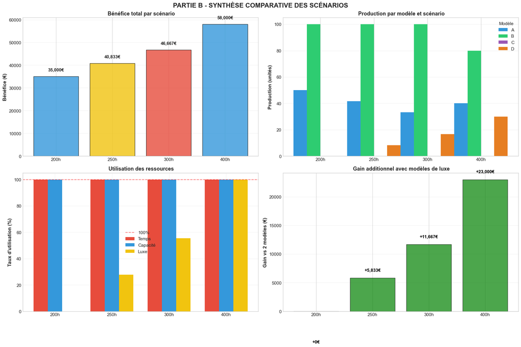

```
                                   CONCLUSIONS
================================================================================
 SCÉNARIO OPTIMAL : 400h
   • Bénéfice : 58,000€
   • Gain vs 2 modèles : +23,000€
   • Production totale : 150 unités

 RECOMMANDATIONS :
1. Augmenter le temps de production est rentable :
   • Gain observé : +23,000€ (65.7%) par rapport au scénario 2 modèles.
2. Prioriser les modèles selon leur rentabilité horaire :
   • 1) B (200 €/h)
   • 2) A (150 €/h)
   • 3) D (125 €/h)
   • 4) C (100 €/h) → à éviter
3. Produire du luxe uniquement quand le temps le permet : 30.0 unités.
   • La limite de 30 unités luxe est atteinte.
4. Les modèles A et B servent à saturer la capacité totale (150 unités) et optimiser le temps.
================================================================================
```

```python
def comparer_scenarios(resultats_200h, resultats_250h, resultats_300h, resultats_400h):
    """Comparaison Viduelle des différents scénarios"""

    # Préparation des données
    scenarios = [
        ("200h", resultats_200h),
        ("250h", resultats_250h),
        ("300h", resultats_300h),
        ("400h", resultats_400h)
    ]

    print("\n" + " PERFORMANCE GLOBALE".center(80))
    print("=" * 80)
    print(f"{'Scénario':<12} {'Bénéfice':<15} {'Gain vs 2m':<15} {'Taux gain':<15} {'Prod tot':<12}")
    print("-" * 80)

    for nom, res in scenarios:
        if res:
            print(f"{nom:<12} {f'{res['benefice']:,.0f}':<15} {f'{res['gain_vs_2_modeles']:+,.0f}':<15} "
                  f"{f'{res['taux_gain']:+.1f}%':<15} {f'{res['capacite_utilisee']:.0f}':<12}")

    print("=" * 80)

    # Graphique de comparaison
    fig, axes = plt.subplots(2, 2, figsize=(18, 12))

    # Graphique 1 : Bénéfice par scénario
    ax1 = axes[0, 0]
    noms = [s[0] for s in scenarios]
    benefices = [s[1]['benefice'] for s in scenarios if s[1]]

    bars = ax1.bar(noms, benefices, color=['#3498db', '#f1c40f', '#e74c3c'],
                  alpha=0.8, edgecolor='black')

    # Ajouter les valeurs sur les barres
    for bar, benef in zip(bars, benefices):
        height = bar.get_height()
        ax1.text(bar.get_x() + bar.get_width()/2., height + 2000,
                f'{benef:,.0f}€', ha='center', va='bottom', fontweight='bold')

    ax1.set_ylabel('Bénéfice (€)', fontsize=12, fontweight='bold')
    ax1.set_title(' Bénéfice total par scénario', fontsize=13, fontweight='bold')
    ax1.grid(True, alpha=0.3, axis='y')

    # Graphique 2 : Production par modèle
    ax2 = axes[0, 1]
    width = 0.25
    x = np.arange(len(noms))

    if all(res[1] for res in scenarios):
        productions_A = [res[1]['x1'] for res in scenarios]
        productions_B = [res[1]['x2'] for res in scenarios]
        productions_C = [res[1]['x3'] for res in scenarios]
        productions_D = [res[1]['x4'] for res in scenarios]

        ax2.bar(x - 1.5*width, productions_A, width, label='A', color='#3498db')
        ax2.bar(x - 0.5*width, productions_B, width, label='B', color='#2ecc71')
        ax2.bar(x + 0.5*width, productions_C, width, label='C', color='#9b59b6')
        ax2.bar(x + 1.5*width, productions_D, width, label='D', color='#e67e22')

        ax2.set_xticks(x)
        ax2.set_xticklabels(noms)
        ax2.set_ylabel('Production (unités)', fontsize=12, fontweight='bold')
        ax2.set_title(' Production par modèle et scénario', fontsize=13, fontweight='bold')
        ax2.legend(title='Modèle')
        ax2.grid(True, alpha=0.3, axis='y')

    # Graphique 3 : Utilisation des ressources
    ax3 = axes[1, 0]

    taux_temps = [100*res[1]['temps_utilise']/res[1]['temps_utilise']
                  for res in scenarios if res[1]]
    taux_capacite = [100*res[1]['capacite_utilisee']/150
                     for res in scenarios if res[1]]
    taux_luxe = [100*res[1]['luxe_utilise']/30
                 for res in scenarios if res[1]]

    x = np.arange(len(noms))
    width = 0.25

    ax3.bar(x - width, taux_temps, width, label='Temps', color='#e74c3c')
    ax3.bar(x, taux_capacite, width, label='Capacité', color='#3498db')
    ax3.bar(x + width, taux_luxe, width, label='Luxe', color='#f1c40f')

    ax3.axhline(y=100, color='red', linestyle='--', alpha=0.5, label='100%')
    ax3.set_xticks(x)
    ax3.set_xticklabels(noms)
    ax3.set_ylabel('Taux d\'utilisation (%)', fontsize=12, fontweight='bold')
    ax3.set_title(' Utilisation des ressources', fontsize=13, fontweight='bold')
    ax3.legend()
    ax3.grid(True, alpha=0.3)

    # Graphique 4 : Gain vs scénario 2 modèles
    ax4 = axes[1, 1]
    gains = [res[1]['gain_vs_2_modeles'] for res in scenarios if res[1]]

    colors = ['green' if gain > 0 else 'red' for gain in gains]
    bars = ax4.bar(noms, gains, color=colors, alpha=0.7, edgecolor='black')

    # Ajouter les valeurs
    for bar, gain in zip(bars, gains):
        height = bar.get_height()
        ax4.text(bar.get_x() + bar.get_width()/2., height + (1000 if height > 0 else -5000),
                f'{gain:+,.0f}€', ha='center', va='bottom' if height > 0 else 'top',
                fontweight='bold', color='black')

    ax4.axhline(y=0, color='black', linewidth=0.8)
    ax4.set_ylabel('Gain vs 2 modèles (€)', fontsize=12, fontweight='bold')
    ax4.set_title(' Gain additionnel avec modèles de luxe', fontsize=13, fontweight='bold')
    ax4.grid(True, alpha=0.3, axis='y')

    plt.suptitle('PARTIE B - SYNTHÈSE COMPARATIVE DES SCÉNARIOS',
                fontsize=16, fontweight='bold', y=0.98)
    plt.tight_layout()
    plt.savefig('partieB_comparaison_scenarios.png', dpi=150, bbox_inches='tight')
    plt.show()

    # Conclusion
    print("\n" + " CONCLUSIONS".center(80))
    print("=" * 80)

    meilleur_scenario = scenarios[0]
    for scenario in scenarios:
        if scenario[1] and scenario[1]['benefice'] > meilleur_scenario[1]['benefice']:
            meilleur_scenario = scenario

    print(f" SCÉNARIO OPTIMAL : {meilleur_scenario[0]}")
    print(f"   • Bénéfice : {meilleur_scenario[1]['benefice']:,.0f}€")
    print(f"   • Gain vs 2 modèles : {meilleur_scenario[1]['gain_vs_2_modeles']:+,.0f}€")
    print(f"   • Production totale : {meilleur_scenario[1]['capacite_utilisee']:.0f} unités")

    print("\n RECOMMANDATIONS :")

    # Récupération des valeurs du meilleur scénario
    gain_abs = meilleur_scenario[1]['gain_vs_2_modeles']
    gain_rel = meilleur_scenario[1]['taux_gain']
    x1 = meilleur_scenario[1]['x1']
    x2 = meilleur_scenario[1]['x2']
    x3 = meilleur_scenario[1]['x3']
    x4 = meilleur_scenario[1]['x4']



    # 1. Investissement dans le temps

    print("1. Augmenter le temps de production est rentable :")
    print(f"   • Gain observé : +{gain_abs:,.0f}€ ({gain_rel:.1f}%) par rapport au scénario 2 modèles.")

    # 2. Priorisation des modèles selon la rentabilité réelle

    print("2. Prioriser les modèles selon leur rentabilité horaire :")
    print("   • 1) B (200 €/h)")
    print("   • 2) A (150 €/h)")
    print("   • 3) D (125 €/h)")
    print("   • 4) C (100 €/h) → à éviter")

    # 3. Production luxe

    if x3 + x4 < 1e-6:
        print("3. Ne pas produire de luxe : aucun modèle C ou D n'est rentable dans ce scénario.")
    else:
        print(f"3. Produire du luxe uniquement quand le temps le permet : {x3+x4:.1f} unités.")

        if abs((x3 + x4) - 30) < 1e-6:
            print("   • La limite de 30 unités luxe est atteinte.")
        else:
            print("   • La limite luxe n'est pas atteinte, car d'autres modèles sont plus rentables.")

    # 4. Rôle des modèles standard
    print("4. Les modèles A et B servent à saturer la capacité totale (150 unités) et optimiser le temps.")

    print("=" * 80)

# Exécution de la comparaison
if all([resultats_200h, resultats_250h, resultats_300h, resultats_400h]):
    comparer_scenarios(resultats_200h, resultats_250h, resultats_300h, resultats_400h)
```

**Q.3.Etudier l'impact du temps de disponibilité de l'usine sur la stratégie de l'entreprise.**

```python
def etudier_impact_temps():
    """
    Étude de l'impact du temps de production disponible
    sur la stratégie de l'entreprise (modèles A, B, C, D)
    """

    print("\n" + "OBJECTIF DE L'ÉTUDE".center(80))
    print("=" * 80)
    print("Analyser comment la variation du temps de production disponible")
    print("influence les décisions de production et la rentabilité")
    print("=" * 80)

    # PARAMÉTRAGE DE L'ÉTUDE
    temps_values = np.arange(200, 401, 50)  # 200h, 250h, 300h, 350h, 400h
    resultats_complets = []

    print(f"Nombre de scénarios analysés : {len(temps_values)}")
    print("=" * 80)

    # BOUCLE D'ANALYSE
    for temps in temps_values:
        # Formulation PL
        c = [-300, -200, -500, -1000]
        A_ub = np.array([
            [2, 1, 5, 8],   # Temps
            [1, 1, 1, 1],   # Capacité totale
            [0, 0, 1, 1]    # Luxe
        ])
        b_ub = np.array([temps, 150, 30])
        bounds = [(0, 100), (0, 100), (0, 30), (0, 30)]

        result = so.linprog(c=c, A_ub=A_ub, b_ub=b_ub, bounds=bounds, method='highs')

        if result.success:
            x1, x2, x3, x4 = result.x
            benefice = -result.fun

            # Métriques
            temps_utilise = 2*x1 + x2 + 5*x3 + 8*x4
            total_production = x1 + x2 + x3 + x4
            luxe_production = x3 + x4

            rentabilite_globale = benefice / temps_utilise if temps_utilise > 0 else 0

            benefice_standard = 300*x1 + 200*x2
            benefice_luxe = 500*x3 + 1000*x4

            # Contraintes actives réelles
            contraintes_actives = []
            if abs(temps_utilise - temps) < 1e-6:
                contraintes_actives.append("Temps")
            if abs(total_production - 150) < 1e-6:
                contraintes_actives.append("Capacité")
            if abs(luxe_production - 30) < 1e-6:
                contraintes_actives.append("Luxe")

            resultats_complets.append({
                'temps_disponible': temps,
                'x1': x1,
                'x2': x2,
                'x3': x3,
                'x4': x4,
                'benefice': benefice,
                'temps_utilise': temps_utilise,
                'total_production': total_production,
                'luxe_production': luxe_production,
                'benefice_standard': benefice_standard,
                'benefice_luxe': benefice_luxe,
                'rentabilite_globale': rentabilite_globale,
                'contraintes_actives': contraintes_actives,
                'taux_utilisation': 100 * temps_utilise / temps if temps > 0 else 0
            })

    df_impact = pd.DataFrame(resultats_complets)

    # IDENTIFICATION DES ZONES STRATÉGIQUES
    print("\n" + " IDENTIFICATION DES ZONES STRATÉGIQUES".center(80))
    print("=" * 80)

    # Ruptures basées sur le luxe
    zones_rupture = []
    for i in range(1, len(df_impact)):
        if df_impact['luxe_production'].iloc[i] != df_impact['luxe_production'].iloc[i-1]:
            zones_rupture.append(df_impact['temps_disponible'].iloc[i])

    print("\n Points de rupture détectés :")
    if zones_rupture:
        for zone in zones_rupture:
            print(f"  • Autour de {zone:.0f} heures")
    else:
        print("  • Évolution progressive sans rupture marquée")

    # Régimes de production (contraintes actives)
    regimes = []
    current = None
    for i in range(len(df_impact)):
        contraintes = df_impact['contraintes_actives'].iloc[i]
        temps = df_impact['temps_disponible'].iloc[i]

        if current is None or contraintes != current['contraintes']:
            if current:
                regimes.append(current)
            current = {'debut': temps, 'fin': temps, 'contraintes': contraintes}
        else:
            current['fin'] = temps

    if current:
        regimes.append(current)

    print("\n Régimes de production identifiés :")
    for regime in regimes:
        if regime['debut'] == regime['fin']:
            print(f"  • À {regime['debut']:.0f}h : Contraintes {regime['contraintes']}")
        else:
            print(f"  • {regime['debut']:.0f}h-{regime['fin']:.0f}h : Contraintes {regime['contraintes']}")

    # VISUALISATION COMPLÈTE
    fig = plt.figure(figsize=(22, 16))
    gs = fig.add_gridspec(3, 3, hspace=0.35, wspace=0.3)

    # Graphique 1 : Évolution du bénéfice
    ax1 = fig.add_subplot(gs[0, :2])
    ax1.plot(df_impact['temps_disponible'], df_impact['benefice'],
             'b-', linewidth=4, marker='o', markersize=6)
    ax1.fill_between(df_impact['temps_disponible'], df_impact['benefice'],
                     alpha=0.2, color='blue')

    for temps_ref in [200, 250, 300, 400]:
        idx = np.abs(df_impact['temps_disponible'] - temps_ref).argmin()
        ax1.plot(temps_ref, df_impact['benefice'].iloc[idx], 'ro', markersize=8)
        ax1.annotate(f'{temps_ref}h\n{df_impact["benefice"].iloc[idx]:,.0f}€',
                     xy=(temps_ref, df_impact['benefice'].iloc[idx]),
                     xytext=(10, 10), textcoords='offset points',
                     fontsize=9, fontweight='bold',
                     bbox=dict(boxstyle='round', facecolor='yellow', alpha=0.8))

    ax1.set_xlabel('Temps de production disponible (heures)', fontsize=13, fontweight='bold')
    ax1.set_ylabel('Bénéfice optimal (€)', fontsize=13, fontweight='bold')
    ax1.set_title(' Évolution du bénéfice en fonction du temps disponible',
                  fontsize=14, fontweight='bold', pad=15)
    ax1.grid(True, alpha=0.3, linestyle='--')

    # Graphique 2 : Rentabilité marginale
    ax2 = fig.add_subplot(gs[0, 2])
    rentabilite_marginale = np.gradient(df_impact['benefice']) / np.gradient(df_impact['temps_disponible'])

    ax2.plot(df_impact['temps_disponible'], rentabilite_marginale,
             'g-', linewidth=3, marker='s', markersize=5)
    ax2.fill_between(df_impact['temps_disponible'], rentabilite_marginale,
                     alpha=0.2, color='green')

    ax2.axhline(y=0, color='red', linestyle='--', alpha=0.5)
    ax2.set_xlabel('Temps disponible (h)', fontsize=12, fontweight='bold')
    ax2.set_ylabel('Rentabilité marginale (€/h)', fontsize=12, fontweight='bold', color='green')
    ax2.set_title(' Rentabilité marginale du temps additionnel',
                  fontsize=13, fontweight='bold', pad=15)
    ax2.grid(True, alpha=0.3)
```

```python
    # Graphique 3 : Production par segment
    ax3 = fig.add_subplot(gs[1, 0])
    ax3.plot(df_impact['temps_disponible'], df_impact['x1'] + df_impact['x2'],
             'b-', linewidth=2.5, label='Standard (A+B)', alpha=0.8)
    ax3.plot(df_impact['temps_disponible'], df_impact['x3'] + df_impact['x4'],
             'r-', linewidth=2.5, label='Luxe (C+D)', alpha=0.8)
    ax3.fill_between(df_impact['temps_disponible'],
                     df_impact['x1'] + df_impact['x2'], alpha=0.3, color='blue')
    ax3.fill_between(df_impact['temps_disponible'],
                     df_impact['x3'] + df_impact['x4'], alpha=0.3, color='red')

    ax3.set_xlabel('Temps disponible (h)', fontsize=12, fontweight='bold')
    ax3.set_ylabel('Production (unités)', fontsize=12, fontweight='bold')
    ax3.set_title(' Évolution de la production par segment',
                  fontsize=13, fontweight='bold', pad=15)
    ax3.legend(fontsize=11)
    ax3.grid(True, alpha=0.3)

    # Graphique 4 : Contribution au bénéfice
    ax4 = fig.add_subplot(gs[1, 1])
    width = 0.8
    x = df_impact['temps_disponible']
    bottom = np.zeros(len(x))

    ax4.bar(x, df_impact['benefice_standard'], width,
            label='Bénéfice Standard', color='blue', alpha=0.7, bottom=bottom)
    bottom += df_impact['benefice_standard']

    ax4.bar(x, df_impact['benefice_luxe'], width,
            label='Bénéfice Luxe', color='red', alpha=0.7, bottom=bottom)

    ax4.set_xlabel('Temps disponible (h)', fontsize=12, fontweight='bold')
    ax4.set_ylabel('Bénéfice (€)', fontsize=12, fontweight='bold')
    ax4.set_title(' Contribution des segments au bénéfice',
                  fontsize=13, fontweight='bold', pad=15)
    ax4.legend(fontsize=11)
    ax4.grid(True, alpha=0.3, axis='y')

    # Graphique 5 : Taux d'utilisation
    ax5 = fig.add_subplot(gs[1, 2])
    ax5.plot(df_impact['temps_disponible'], df_impact['taux_utilisation'],
             'purple', linewidth=3, marker='D', markersize=5)
    ax5.fill_between(df_impact['temps_disponible'], df_impact['taux_utilisation'],
                     alpha=0.2, color='purple')

    ax5.axhline(y=100, color='red', linestyle='--', alpha=0.5, label='100%')
    ax5.set_xlabel('Temps disponible (h)', fontsize=12, fontweight='bold')
    ax5.set_ylabel("Taux d'utilisation (%)", fontsize=12, fontweight='bold')
    ax5.set_title(" Taux d'utilisation du temps disponible",
                  fontsize=13, fontweight='bold', pad=15)
    ax5.grid(True, alpha=0.3)
    ax5.legend()

    # Graphique 6 : Mix produit optimal
    ax6 = fig.add_subplot(gs[2, 0])
    ax6.stackplot(df_impact['temps_disponible'],
                  df_impact['x1'], df_impact['x2'], df_impact['x3'], df_impact['x4'],
                  colors=['#3498db', '#2ecc71', '#9b59b6', '#e67e22'],
                  labels=['A', 'B', 'C', 'D'])

    ax6.set_xlabel('Temps disponible (h)', fontsize=12, fontweight='bold')
    ax6.set_ylabel('Production (unités)', fontsize=12, fontweight='bold')
    ax6.set_title(' Composition optimale de la production',
                  fontsize=13, fontweight='bold', pad=15)
    ax6.legend(title='Modèles', fontsize=10, title_fontsize=11)
    ax6.grid(True, alpha=0.3)

    # Graphique 7 : Contraintes actives
    ax7 = fig.add_subplot(gs[2, 1:])

    contraintes_uniques = set()
    for contraintes in df_impact['contraintes_actives']:
        contraintes_uniques.update(contraintes)
    contraintes_uniques = sorted(contraintes_uniques)

    heatmap_data = np.zeros((len(contraintes_uniques), len(df_impact)))
    for i, contraintes in enumerate(df_impact['contraintes_actives']):
        for j, contrainte in enumerate(contraintes_uniques):
            heatmap_data[j, i] = 1 if contrainte in contraintes else 0

    im = ax7.imshow(heatmap_data, cmap='RdYlGn', aspect='auto',
                    extent=[df_impact['temps_disponible'].min(),
                            df_impact['temps_disponible'].max(),
                            0, len(contraintes_uniques)])

    ax7.set_yticks(np.arange(len(contraintes_uniques)) + 0.5)
    ax7.set_yticklabels(contraintes_uniques)
    ax7.set_xlabel('Temps disponible (h)', fontsize=12, fontweight='bold')
    ax7.set_title(' Contraintes actives par niveau de temps',
                  fontsize=13, fontweight='bold', pad=15)

    for rupture in zones_rupture:
        ax7.axvline(x=rupture, color='blue', linestyle='--', alpha=0.5)

    plt.colorbar(im, ax=ax7, label='Contrainte active')

    plt.suptitle(
        "ÉTUDE STRATÉGIQUE : IMPACT DU TEMPS DE PRODUCTION DISPONIBLE\n"
        "Analyse complète de la sensibilité aux ressources temporelles",
        fontsize=16, fontweight='bold', y=0.98
    )

    plt.tight_layout()
    plt.savefig('etude_strategique_temps.png', dpi=150, bbox_inches='tight')
    plt.show()

    # ANALYSE DÉTAILLÉE PAR ZONE
    print("\n" + " ANALYSE DÉTAILLÉE PAR ZONE".center(80))
    print("=" * 80)

    zones = [
        (200, 200, "Zone 1 : Aucun luxe (A+B uniquement)"),
        (220, 260, "Zone 2 : Apparition du luxe (D)"),
        (260, 340, "Zone 3 : Luxe croissant"),
        (340, 400, "Zone 4 : Luxe saturé (30 unités)")
    ]

    for debut, fin, nom in zones:
        mask = (df_impact['temps_disponible'] >= debut) & (df_impact['temps_disponible'] <= fin)
        zone_data = df_impact[mask]

        if len(zone_data) > 0:
            print(f"\n{nom}")
            print("-" * 80)
            print(f"• Temps : {debut}-{fin}h")
            print(f"• Bénéfice moyen : {zone_data['benefice'].mean():,.0f}€")
            print(f"• Production moyenne : {zone_data['total_production'].mean():.1f} unités")
            if zone_data['total_production'].mean() > 0:
                part_luxe = 100 * zone_data['luxe_production'].mean() / zone_data['total_production'].mean()
            else:
                part_luxe = 0
            print(f"• Part luxe moyenne : {part_luxe:.1f}%")
            print(f"• Rentabilité moyenne : {zone_data['rentabilite_globale'].mean():.1f}€/h")
            print(f"• Taux d'utilisation moyen : {zone_data['taux_utilisation'].mean():.1f}%")
```

```
                              OBJECTIF DE L'ÉTUDE
================================================================================
Analyser comment la variation du temps de production disponible
influence les décisions de production et la rentabilité
================================================================================
Nombre de scénarios analysés : 5
================================================================================

                      IDENTIFICATION DES ZONES STRATÉGIQUES
================================================================================

 Points de rupture détectés :
  • Autour de 250 heures
  • Autour de 300 heures
  • Autour de 350 heures
  • Autour de 400 heures

 Régimes de production identifiés :
  • 200h-350h : Contraintes ['Temps', 'Capacité']
  • À 400h : Contraintes ['Temps', 'Capacité', 'Luxe']
```

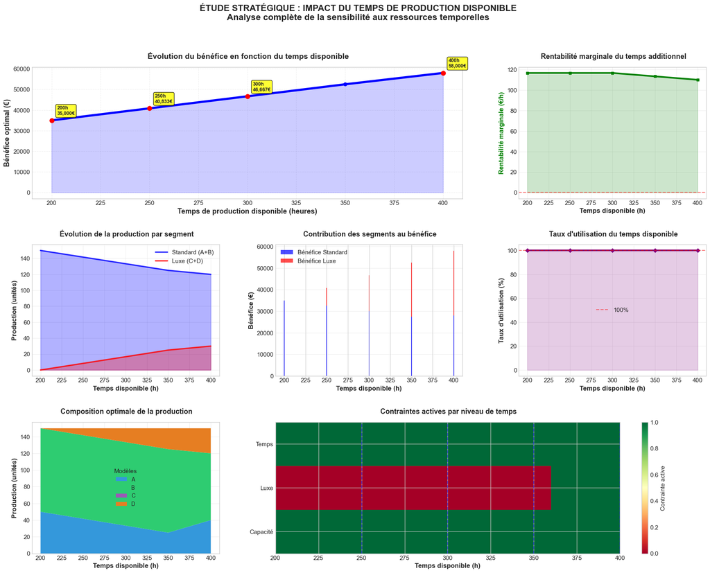

[output not shown]

[output cut: 23 more lines]

```

 Décisions d'investissement :
4. Seuil de rentabilité : 200h (premier scénario rentable)
5. Point de saturation du luxe : 400h
6. Temps optimal recommandé : 400h (bénéfice maximal)

                                   PROJECTIONS
--------------------------------------------------------------------------------
Scénario                  Bénéfice        Gain vs 200h    ROI estimé
--------------------------------------------------------------------------------
Statut quo                35,000          +0              +0.0%
Investissement modéré     40,833          +5,833          +116.7%
Investissement important  46,667          +11,667         +116.7%
Expansion maximale        58,000          +23,000         +115.0%
================================================================================
```

```python
            contraintes_freq = {}
            for contraintes in zone_data['contraintes_actives']:
                for c in contraintes:
                    contraintes_freq[c] = contraintes_freq.get(c, 0) + 1

            if contraintes_freq:
                print(f"• Contraintes fréquentes : {', '.join(sorted(contraintes_freq.keys()))}")

    # RECOMMANDATIONS

    print("\n" + " RECOMMANDATIONS ".center(80))
    print("=" * 80)

    print("\n Pour le management :")
    print("1. Investissement recommandé : augmenter le temps disponible jusqu'à 400h")
    benef_200 = df_impact[df_impact['temps_disponible'] == 200]['benefice'].iloc[0]
    benef_400 = df_impact[df_impact['temps_disponible'] == 400]['benefice'].iloc[0]
    print(f"   • Gain total entre 200h et 400h : {benef_400 - benef_200:,.0f}€")
    print("   • ROI positif sur toute la plage analysée")

    print("\n Pour la production :")
    print("2. Priorités selon les ressources :")
    print("   • < 250h : Produire uniquement A et B (aucun luxe rentable)")
    print("   • 250–300h : Introduire progressivement le modèle D")
    print("   • 300–400h : Augmenter D jusqu'à saturation (30 unités)")
    print("   • Le modèle C n'est jamais optimal (rentabilité trop faible)")

    print("\n Pour le marketing :")
    print("3. Stratégie commerciale :")
    print("   • Segment luxe : potentiel réel uniquement à partir de 250h")
    print("   • Saturation du luxe à 400h → opportunité premium")
    print("   • Segment standard : reste majoritaire (80–95%)")

    print("\n Décisions d'investissement :")
    print("4. Seuil de rentabilité : 200h (premier scénario rentable)")
    print("5. Point de saturation du luxe : 400h")
    print("6. Temps optimal recommandé : 400h (bénéfice maximal)")

    print("\n" + " PROJECTIONS".center(80))
    print("-" * 80)

    investissements = [
        (200, "Statut quo"),
        (250, "Investissement modéré"),
        (300, "Investissement important"),
        (400, "Expansion maximale")
    ]

    print(f"{'Scénario':<25} {'Bénéfice':<15} {'Gain vs 200h':<15} {'ROI estimé':<15}")
    print("-" * 80)

    for temps, scenario in investissements:
        idx = np.abs(df_impact['temps_disponible'] - temps).argmin()
        benefice = df_impact['benefice'].iloc[idx]
        gain = benefice - benef_200
        investissement = max(temps - 200, 0) * 100  # 100€/h d'investissement
        roi = 100 * gain / investissement if investissement > 0 else 0

        print(f"{scenario:<25} {f'{benefice:,.0f}':<15} {f'{gain:+,.0f}':<15} {f'{roi:+.1f}%':<15}")

    print("=" * 80)

    return df_impact


# EXÉCUTION DE L'ÉTUDE
df_etude_temps = etudier_impact_temps()
```

L'usine fait remarquer que les flux de matières premières sont tendus et demande de les prendre en compte. L'entreprise dispose également de ressources limitées en matières premières :

| Matière | Modèle A | Modèle B | Stock disponible |
| --- | --- | --- | --- |
| Bois | 2 unités | 1 unité | 125 unités |
| Visserie | 0.2 kg | 0.2 kg | 55 kg |
| Aluminium | 1 m | 1 m | 300 m |
| Acier | 2 kg | 2 kg | 100 kg |
| Caoutchouc | 1 m² | 1 m² | 60 m² |
| Mousse | 1 m³ | 1 m³ | 100 m³ |
| Tissu | 2 m | 2 m | 220 m |

```python
print("\n" + " FORMULATION DU PROBLÈME".center(80))
print("-" * 80)
print("Variables : x₁ (modèle A), x₂ (modèle B)")
print("\nFonction objectif :")
print("  max Z = 300x₁ + 200x₂")
print("\nContraintes additionnelles :")
print("  • 2x₁ + x₂ ≤ 125  (Bois)")
print("  • 0.2x₁ + 0.2x₂ ≤ 55  (Visserie)")
print("  • x₁ + x₂ ≤ 300  (Aluminium)")
print("  • 2x₁ + 2x₂ ≤ 100  (Acier)")
print("  • x₁ + x₂ ≤ 60  (Caoutchouc)")
print("  • x₁ + x₂ ≤ 100  (Mousse)")
print("  • 2x₁ + 2x₂ ≤ 220  (Tissu)")
print("+ contraintes initiales (Temps, Capacité, Marché)")
print("-" * 80)
```

```
                             FORMULATION DU PROBLÈME
--------------------------------------------------------------------------------
Variables : x₁ (modèle A), x₂ (modèle B)

Fonction objectif :
  max Z = 300x₁ + 200x₂

Contraintes additionnelles :
  • 2x₁ + x₂ ≤ 125  (Bois)
  • 0.2x₁ + 0.2x₂ ≤ 55  (Visserie)
  • x₁ + x₂ ≤ 300  (Aluminium)
  • 2x₁ + 2x₂ ≤ 100  (Acier)
  • x₁ + x₂ ≤ 60  (Caoutchouc)
  • x₁ + x₂ ≤ 100  (Mousse)
  • 2x₁ + 2x₂ ≤ 220  (Tissu)
+ contraintes initiales (Temps, Capacité, Marché)
--------------------------------------------------------------------------------
```

```python
def resoudre_partie_C_avec_matieres():
    """
    Résolution complète avec toutes les contraintes de matières premières
    """

    print("\n" + " OPTIMISATION AVEC MATIÈRES PREMIÈRES".center(80))
    print("=" * 80)

    c = [-300, -200]  # Coûts (négatifs pour maximisation)

    # Matrice des contraintes
    A_ub = np.array([
        # Contraintes initiales
        [2, 1],        # Temps de production
        [1, 1],        # Capacité de vente

        # Contraintes de matières premières
        [2, 1],        # Bois
        [0.2, 0.2],    # Visserie
        [1, 1],        # Aluminium
        [2, 2],        # Acier
        [1, 1],        # Caoutchouc
        [1, 1],        # Mousse
        [2, 2],        # Tissu
    ])

    b_ub = np.array([200, 150, 125, 55, 300, 100, 60, 100, 220])

    # Noms des contraintes pour l'affichage
    noms_contraintes = [
        '⏱️  Temps', '📦 Capacité', '🌳 Bois', '🔩 Visserie',
        '🔧 Aluminium', '⚙️  Acier', '🛞 Caoutchouc',
        '🧽 Mousse', '👕 Tissu'
    ]

    # Bornes (marché)
    bounds = [(0, 100), (0, 100)]

    print("\n" + " Résolution du problème de PL...".center(80))


    # RÉSOLUTION

    result = so.linprog(c=c, A_ub=A_ub, b_ub=b_ub, bounds=bounds, method='highs')

    if result.success:
        x1, x2 = result.x
        benefice = -result.fun

        # Section 1 : Production optimale
        print("\n" + " PRODUCTION OPTIMALE".center(80))
        print("=" * 80)
        print(f"│ {'Modèle A :':<30} {f'{x1:.1f}':>20} unités │")
        print(f"│ {'Modèle B :':<30} {f'{x2:.1f}':>20} unités │")
        print(f"│ {'Total :':<30} {f'{x1+x2:.1f}':>20} unités │")
        print("=" * 80)

        # Section 2 : Bénéfice et comparaison
        print("\n" + " ANALYSE FINANCIÈRE".center(80))
        print("-" * 80)
        print(f"│ {'Bénéfice optimal :':<40} {f'{benefice:,.0f}':>25} € │")
        print("-" * 80)

        # Comparaison avec le cas sans matières
        print(f"\n COMPARAISON AVEC LE CAS SANS MATIÈRES :")
        print("-" * 80)

        donnees_comparatives = [
            ("Production A", x1_base, x1, x1 - x1_base),
            ("Production B", x2_base, x2, x2 - x2_base),
            ("Production totale", x1_base + x2_base, x1 + x2,
             (x1 + x2) - (x1_base + x2_base)),
            ("Bénéfice", benefice_base, benefice, benefice - benefice_base)
        ]

        print(f"{'Indicateur':<25} {'Sans MP':<15} {'Avec MP':<15} {'Différence':<15}")
        print("-" * 80)

        for nom, sans, avec, diff in donnees_comparatives:
            if "Bénéfice" in nom:
                fmt_sans = f"{sans:,.0f}"
                fmt_avec = f"{avec:,.0f}"
                fmt_diff = f"{diff:+,.0f}"
                pourcent = f"({100*diff/sans:+.1f}%)" if sans != 0 else ""
            else:
                fmt_sans = f"{sans:.1f}"
                fmt_avec = f"{avec:.1f}"
                fmt_diff = f"{diff:+.1f}"
                pourcent = f"({100*diff/sans:+.1f}%)" if sans != 0 else ""

            print(f"{nom:<25} {fmt_sans:>15} {fmt_avec:>15} {fmt_diff:>10} {pourcent:>5}")

        print("=" * 80)


        # ANALYSE DES CONTRAINTES SATURÉES

        print("\n" + " ANALYSE DES GOULOTS D'ÉTRANGLEMENT".center(80))
        print("=" * 80)

        # Calcul de l'utilisation de chaque ressource
        utilisation = A_ub @ result.x

        contraintes_detaillees = []
        for i, (nom, util, dispo) in enumerate(zip(noms_contraintes, utilisation, b_ub)):
            taux = 100 * util / dispo if dispo > 0 else 0
            statut = "🔴 SATURÉ" if taux > 99 else "🟠 TENDUE" if taux > 90 else "🟢 LIBRE"

            contraintes_detaillees.append({
                'nom': nom,
                'utilise': util,
                'disponible': dispo,
                'taux': taux,
                'statut': statut,
                'marge': dispo - util
            })

        # Trier par taux d'utilisation décroissant
        contraintes_detaillees.sort(key=lambda x: x['taux'], reverse=True)

        print(f"\n{'Statut':<10} {'Contrainte':<15} {'Utilisé':<12} {'Disponible':<12} {'Taux':<10} {'Marge':<10}")
        print("-" * 80)

        for c in contraintes_detaillees:
            if 'Temps' in c['nom'] or 'Capacité' in c['nom'] or c['taux'] > 50:
                print(f"{c['statut']:<10} {c['nom']:<15} {f'{c['utilise']:.1f}':<12} "
                      f"{f'{c['disponible']:.0f}':<12} {f'{c['taux']:.1f}%':<10} "
                      f"{f'{c['marge']:.1f}':<10}")


        # IDENTIFICATION DES CONTRAINTES LIMITANTES

        print("\n" + " CONTRAINTES LIMITANTES (à >90%)".center(80))
        print("-" * 80)

        contraintes_limitantes = [c for c in contraintes_detaillees if c['taux'] > 90]

        if contraintes_limitantes:
            print("Les ressources suivantes limitent fortement la production :")
            for c in contraintes_limitantes:
                print(f"  • {c['nom']} : {c['taux']:.1f}% utilisé "
                      f"(marge : {c['marge']:.1f})")
        else:
            print("Aucune contrainte fortement limitante identifiée")

        print("-" * 80)


        # ANALYSE DE SENSIBILITÉ AUX MATIÈRES PREMIÈRES

        print("\n" + " ANALYSE DE SENSIBILITÉ".center(80))
        print("=" * 80)

        # Analyse simplifiée sans boucle d'optimisation
        print("Estimation de l'impact des contraintes les plus limitantes :")
        print("-" * 80)

        # Identifier les 3 contraintes les plus limitantes
        contraintes_lim = contraintes_detaillees[:3]

        print(f"{'Contrainte':<15} {'Taux actuel':<12} {'Impact estimé':<15}")
        print("-" * 80)

        for c in contraintes_lim:
            # Estimation simple de l'impact
            if c['taux'] > 95:
                impact_estime = f"TRÈS FORT"
            elif c['taux'] > 85:
                impact_estime = f"FORT"
            elif c['taux'] > 70:
                impact_estime = f"MODÉRÉ"
            else:
                impact_estime = f"FAIBLE"

            print(f"{c['nom']:<15} {f'{c['taux']:.1f}%':<12} {impact_estime:<15}")
```

```python
        print("=" * 80)

        # VISUALISATION DES CONTRAINTES

        print("\n" + " GÉNÉRATION DES VISUALISATIONS".center(80))

        fig, axes = plt.subplots(2, 2, figsize=(18, 12))

        # Graphique 1 : Taux d'utilisation des ressources
        ax1 = axes[0, 0]
        noms_court = [c.replace('⏱️  ', '').replace('📦 ', '').replace('🌳 ', '')
                     .replace('🔩 ', '').replace('🔧 ', '').replace('⚙️  ', '')
                     .replace('🛞 ', '').replace('🧽 ', '').replace('👕 ', '')
                     for c in noms_contraintes]
        taux_utilisation = [c['taux'] for c in contraintes_detaillees]

        colors = ['red' if t > 95 else 'orange' if t > 80 else 'green'
                 for t in taux_utilisation]

        bars = ax1.barh(noms_court, taux_utilisation, color=colors, alpha=0.7)
        ax1.axvline(x=100, color='red', linestyle='--', alpha=0.5)
        ax1.axvline(x=80, color='orange', linestyle='--', alpha=0.3)

        # Ajouter les valeurs
        for bar, taux in zip(bars, taux_utilisation):
            ax1.text(min(taux + 1, 99), bar.get_y() + bar.get_height()/2,
                   f'{taux:.1f}%', va='center', fontweight='bold')

        ax1.set_xlabel('Taux d\'utilisation (%)', fontsize=12, fontweight='bold')
        ax1.set_title(' Utilisation des ressources', fontsize=13, fontweight='bold')
        ax1.set_xlim(0, 110)

        # Graphique 2 : Comparaison production avec/sans MP
        ax2 = axes[0, 1]
        categories = ['Modèle A', 'Modèle B', 'Total']
        sans_mp = [x1_base, x2_base, x1_base + x2_base]
        avec_mp = [x1, x2, x1 + x2]

        x = np.arange(len(categories))
        width = 0.35

        bars1 = ax2.bar(x - width/2, sans_mp, width, label='Sans contraintes MP',
                       color='lightblue', alpha=0.8)
        bars2 = ax2.bar(x + width/2, avec_mp, width, label='Avec contraintes MP',
                       color='lightcoral', alpha=0.8)

        ax2.set_ylabel('Production (unités)', fontsize=12, fontweight='bold')
        ax2.set_title(' Impact des contraintes MP sur la production',
                     fontsize=13, fontweight='bold')
        ax2.set_xticks(x)
        ax2.set_xticklabels(categories)
        ax2.legend()

        # Graphique 3 : Marges de sécurité
        ax3 = axes[1, 0]
        marges = [c['marge'] for c in contraintes_detaillees]
        noms_marge = noms_court

        colors_marge = ['red' if m < 5 else 'orange' if m < 20 else 'green'
                       for m in marges]

        bars3 = ax3.barh(noms_marge, marges, color=colors_marge, alpha=0.7)

        # Ajouter les valeurs
        for bar, marge in zip(bars3, marges):
            ax3.text(marge + max(marges)*0.01, bar.get_y() + bar.get_height()/2,
                   f'{marge:.1f}', va='center', fontweight='bold')

        ax3.set_xlabel('Marge de sécurité', fontsize=12, fontweight='bold')
        ax3.set_title(' Marges de sécurité des ressources',
                     fontsize=13, fontweight='bold')

        # Graphique 4 : Contribution aux goulots
        ax4 = axes[1, 1]
        contraintes_limitantes_data = [c for c in contraintes_detaillees if c['taux'] > 80]

        if contraintes_limitantes_data:
            noms_lim = [c['nom'] for c in contraintes_limitantes_data]
            taux_lim = [c['taux'] for c in contraintes_limitantes_data]

            wedges, texts, autotexts = ax4.pie(taux_lim, labels=noms_lim, autopct='%1.1f%%',
                                              startangle=90, counterclock=False)

            # Améliorer la lisibilité
            for autotext in autotexts:
                autotext.set_color('white')
                autotext.set_fontweight('bold')

            ax4.set_title(' Répartition des contraintes limitantes',
                         fontsize=13, fontweight='bold')
        else:
            ax4.text(0.5, 0.5, 'Aucun goulot d\'étranglement\nsignificatif détecté',
                    ha='center', va='center', fontsize=12, fontweight='bold')
            ax4.set_title(' Situation optimale', fontsize=13, fontweight='bold')

        plt.suptitle('PARTIE C - ANALYSE DES CONTRAINTES DE MATIÈRES PREMIÈRES',
                    fontsize=16, fontweight='bold', y=0.98)
        plt.tight_layout()
        plt.savefig('partieC_analyse_matieres.png', dpi=150, bbox_inches='tight')
        plt.show()

        print(" Graphique sauvegardé : partieC_analyse_matieres.png")


        # RECOMMANDATIONS

        print("\n" + " RECOMMANDATIONS OPÉRATIONNELLES".center(80))
        print("=" * 80)

        # Identifier les actions prioritaires
        actions_prioritaires = []

        for c in contraintes_detaillees:
            if c['taux'] > 95:
                actions_prioritaires.append(
                    f"1. URGENT : Augmenter les stocks de {c['nom']} "
                    f"(marge : {c['marge']:.1f})"
                )
            elif c['taux'] > 85:
                actions_prioritaires.append(
                    f"2. IMPORTANT : Surveiller {c['nom']} "
                    f"(utilisation : {c['taux']:.1f}%)"
                )

        if actions_prioritaires:
            print("🔴 ACTIONS PRIORITAIRES :")
            for action in actions_prioritaires[:3]:  # Top 3
                print(f"  {action}")
        else:
            print(" Situation stable, pas d'action urgente nécessaire")

        print(f"\n STRATÉGIE D'APPROVISIONNEMENT :")
        if contraintes_detaillees:
            print(f"   • Priorité 1 : {contraintes_detaillees[0]['nom']}")
            if len(contraintes_detaillees) > 1:
                print(f"   • Priorité 2 : {contraintes_detaillees[1]['nom']}")
            if len(contraintes_detaillees) > 2:
                print(f"   • Priorité 3 : {contraintes_detaillees[2]['nom']}")

        print(f"\n OPTIMISATION DE PRODUCTION :")
        print(f"   • Production maximale possible : {x1+x2:.0f} unités")
        print(f"   • Bénéfice actuel : {benefice:,.0f}€")
        print(f"   • Potentiel perdu : {benefice_base - benefice:,.0f}€ "
              f"({100*(benefice_base-benefice)/benefice_base:.1f}%)")
```

```
                      OPTIMISATION AVEC MATIÈRES PREMIÈRES
================================================================================

                         Résolution du problème de PL...

                               PRODUCTION OPTIMALE
================================================================================
│ Modèle A :                                     50.0 unités │
│ Modèle B :                                      0.0 unités │
│ Total :                                        50.0 unités │
================================================================================

                               ANALYSE FINANCIÈRE
--------------------------------------------------------------------------------
│ Bénéfice optimal :                                          15,000 € │
--------------------------------------------------------------------------------

 COMPARAISON AVEC LE CAS SANS MATIÈRES :
--------------------------------------------------------------------------------
Indicateur                Sans MP         Avec MP         Différence
--------------------------------------------------------------------------------
Production A                         50.0            50.0       +0.0 (+0.0%)
Production B                        100.0             0.0     -100.0 (-100.0%)
Production totale                   150.0            50.0     -100.0 (-66.7%)
Bénéfice                           35,000          15,000    -20,000 (-57.1%)
================================================================================

                       ANALYSE DES GOULOTS D'ÉTRANGLEMENT
================================================================================

Statut     Contrainte      Utilisé      Disponible   Taux       Marge
--------------------------------------------------------------------------------
🔴 SATURÉ   ⚙️  Acier       100.0        100          100.0%     0.0
🟢 LIBRE    🛞 Caoutchouc    50.0         60           83.3%      10.0
🟢 LIBRE    🌳 Bois          100.0        125          80.0%      25.0
🟢 LIBRE    ⏱️  Temps       100.0        200          50.0%      100.0
🟢 LIBRE    📦 Capacité      50.0         150          33.3%      100.0

                         CONTRAINTES LIMITANTES (à >90%)
--------------------------------------------------------------------------------
Les ressources suivantes limitent fortement la production :
  • ⚙️  Acier : 100.0% utilisé (marge : 0.0)
--------------------------------------------------------------------------------

                             ANALYSE DE SENSIBILITÉ
================================================================================
Estimation de l'impact des contraintes les plus limitantes :
--------------------------------------------------------------------------------
Contrainte      Taux actuel  Impact estimé
--------------------------------------------------------------------------------
⚙️  Acier       100.0%       TRÈS FORT
🛞 Caoutchouc    83.3%        MODÉRÉ
🌳 Bois          80.0%        MODÉRÉ
================================================================================

                          GÉNÉRATION DES VISUALISATIONS
```

[figure not shown]

```
 Graphique sauvegardé : partieC_analyse_matieres.png

                         RECOMMANDATIONS OPÉRATIONNELLES
================================================================================
🔴 ACTIONS PRIORITAIRES :
  1. URGENT : Augmenter les stocks de ⚙️  Acier (marge : 0.0)

 STRATÉGIE D'APPROVISIONNEMENT :
   • Priorité 1 : ⚙️  Acier
   • Priorité 2 : 🛞 Caoutchouc
   • Priorité 3 : 🌳 Bois

 OPTIMISATION DE PRODUCTION :
   • Production maximale possible : 50 unités
   • Bénéfice actuel : 15,000€
   • Potentiel perdu : 20,000€ (57.1%)
================================================================================

                                     RÉSUMÉ
================================================================================

 SITUATION ACTUELLE :
   • Production : 50A + 0B = 50 unités
   • Bénéfice : 15,000€
   • Taux d'utilisation moyen : 53.0%

  PRINCIPAUX RISQUES :
   • ⚙️  Acier : 100.0% (marge : 0.0)

 RECOMMANDATIONS :
   1. Investir dans l'augmentation des stocks critiques
   2. Diversifier les sources d'approvisionnement
   3. Optimiser les consommations unitaires
   4. Mettre en place des stocks de sécurité
================================================================================
```

```python
        print("=" * 80)


        # RÉSUMÉ EXÉCUTIF

        print("\n" + " RÉSUMÉ".center(80))
        print("=" * 80)

        print(f"\n SITUATION ACTUELLE :")
        print(f"   • Production : {x1:.0f}A + {x2:.0f}B = {x1+x2:.0f} unités")
        print(f"   • Bénéfice : {benefice:,.0f}€")
        print(f"   • Taux d'utilisation moyen : {np.mean(taux_utilisation):.1f}%")

        print(f"\n  PRINCIPAUX RISQUES :")
        goulots_majeurs = [c for c in contraintes_detaillees if c['taux'] > 95]
        if goulots_majeurs:
            for g in goulots_majeurs:
                print(f"   • {g['nom']} : {g['taux']:.1f}% (marge : {g['marge']:.1f})")
        else:
            print(f"   • Aucun risque majeur identifié")

        print(f"\n RECOMMANDATIONS :")
        print(f"   1. Investir dans l'augmentation des stocks critiques")
        print(f"   2. Diversifier les sources d'approvisionnement")
        print(f"   3. Optimiser les consommations unitaires")
        print(f"   4. Mettre en place des stocks de sécurité")

        print("=" * 80)

        # Retourner les résultats principaux comme simples valeurs
        return x1, x2, benefice, contraintes_detaillees

    else:
        print("\n" + "❌" * 20)
        print("ÉCHEC DE LA RÉSOLUTION".center(80))
        print("❌" * 20)
        print(f"\nMessage d'erreur : {result.message}")
        return None, None, None, None


# EXÉCUTION DE L'ANALYSE

x1_C, x2_C, benefice_C, contraintes_C = resoudre_partie_C_avec_matieres()
```

```python
def resoudre_probleme_complet():
    """Résolution du problème complet avec 4 modèles et toutes les contraintes"""

    print("\n FORMULATION DU PROBLÈME".center(80))
    print("=" * 80)
    print("Variables : x₁(A), x₂(B), x₃(C), x₄(D)")
    print("\nObjectif : max Z = 300x₁ + 200x₂ + 500x₃ + 1000x₄")
    print("\nContraintes intégrées :")
    print("• Temps, capacité totale, demande luxe")
    print("• Toutes les matières premières pour A et B")
    print("• Limites de marché individuelles")
    print("=" * 80)

    # Fonction objectif (négative car linprog minimise)
    c = [-300, -200, -500, -1000]

    # Matrice des contraintes
    A_ub = np.array([
        [2, 1, 5, 8],     # Temps
        [1, 1, 1, 1],     # Capacité totale
        [0, 0, 1, 1],     # Luxe
        [2, 1, 0, 0],     # Bois
        [0.2, 0.2, 0, 0], # Visserie
        [1, 1, 0, 0],     # Aluminium
        [2, 2, 0, 0],     # Acier
        [1, 1, 0, 0],     # Caoutchouc
        [1, 1, 0, 0],     # Mousse
        [2, 2, 0, 0],     # Tissu
    ])

    # Bornes des contraintes
    b_ub = np.array([
        200, 150, 30,
        125, 55, 300, 100, 60, 100, 220
    ])

    # Bornes des variables
    bounds = [(0, 100), (0, 100), (0, 30), (0, 30)]

    # Résolution
    result = so.linprog(c=c, A_ub=A_ub, b_ub=b_ub, bounds=bounds, method='highs')

    if not result.success:
        print("\n❌ ÉCHEC DE LA RÉSOLUTION")
        print(result.message)
        return None, None, None

    x = result.x
    benefice = -result.fun

    # --- AFFICHAGE DES RÉSULTATS ---

    print("\n PRODUCTION OPTIMALE :")
    print("-" * 80)
    noms = ["A", "B", "C", "D"]
    prix = [300, 200, 500, 1000]

    for i in range(4):
        print(f"• Modèle {noms[i]} : {x[i]:6.2f} unités → {x[i]*prix[i]:8,.0f} €")

    print("-" * 80)
    print(f"Total production : {sum(x):6.2f} unités")
    print(f"Total luxe (C+D) : {x[2] + x[3]:6.2f} unités")

    print(f"\n BÉNÉFICE TOTAL : {benefice:,.0f} €")

    # --- ANALYSE DES CONTRAINTES ---

    print("\n UTILISATION DES RESSOURCES :")
    print("=" * 80)

    utilisation = A_ub @ x
    noms_contraintes = [
        'Temps', 'Capacité', 'Luxe', 'Bois', 'Visserie',
        'Aluminium', 'Acier', 'Caoutchouc', 'Mousse', 'Tissu'
    ]

    taux = []
    for nom, util, dispo in zip(noms_contraintes, utilisation, b_ub):
        taux.append((100 * util / dispo, nom, util, dispo))

    taux.sort(reverse=True)

    print(f"{'Ressource':<15} {'Utilisé':<12} {'Disponible':<12} {'Taux':<10}")
    print("-" * 80)

    for t, nom, util, dispo in taux:
        statut = "🔴" if t > 95 else "🟠" if t > 80 else "🟢"
        print(f"{statut} {nom:<12} {util:7.2f}/{dispo:7.0f}    {t:6.1f}%")

    # --- ANALYSE ÉCONOMIQUE ---

    print("\n ANALYSE ÉCONOMIQUE :")
    print("-" * 80)

    rentabilites = [
        ('B', 200/1),
        ('A', 300/2),
        ('D', 1000/8),
        ('C', 500/5)
    ]

    print("Rentabilité par heure :")
    for m, r in sorted(rentabilites, key=lambda x: x[1], reverse=True):
        print(f"  • Modèle {m} : {r:.0f} €/h")

    print("\nContribution au bénéfice :")
    contribs = [(noms[i], x[i] * prix[i]) for i in range(4)]
    total = sum(c for _, c in contribs)

    for m, c in sorted(contribs, key=lambda x: x[1], reverse=True):
        print(f"  • Modèle {m} : {c:,.0f} € ({100*c/total:.1f}%)")

    # --- RECOMMANDATIONS ---

    print("\n RECOMMANDATIONS :")
    print("=" * 80)

    contraintes_limitantes = [(t, nom) for t, nom, _, _ in taux if t > 90]

    if contraintes_limitantes:
        print("Contraintes à prioriser :")
        for t, nom in contraintes_limitantes:
            print(f"  • {nom} ({t:.1f}% utilisé)")

    print("\nStratégie optimale :")
    print("  • Prioriser B (200 €/h) et A (150 €/h) tant que les matières premières le permettent")
    if x[3] > 0:
        print("  • Utiliser D lorsque les contraintes de matières premières limitent A et B")
    print("  • Le modèle C reste non optimal dans ce scénario")

    print("=" * 80)

    return x, benefice, taux


# --- EXÉCUTION ---

x_opt, benefice_opt, taux_util = resoudre_probleme_complet()

print("\n" + "=" * 80)
print(" SYNTHÈSE DE L'ANALYSE".center(80))
print("=" * 80)

if x_opt is not None:
    print(f"\n SOLUTION OPTIMALE :")
    print(f"  • A: {x_opt[0]:.2f}u, B: {x_opt[1]:.2f}u")
    print(f"  • C: {x_opt[2]:.2f}u, D: {x_opt[3]:.2f}u")
    print(f"  • Bénéfice maximal : {benefice_opt:,.0f} €")

    print("\n On constate :")
    print("  1. Le modèle D améliore le bénéfice lorsque les matières premières limitent A et B")
    print("  2. Les contraintes critiques sont le temps et l’acier")
    print("  3. La contrainte luxe n’est pas saturée dans ce scénario")
    print("  4. Le modèle C reste non optimal")
    print("  5. L’optimisation est cohérente avec les contraintes multiples")
```

```
 FORMULATION DU PROBLÈME
================================================================================
Variables : x₁(A), x₂(B), x₃(C), x₄(D)

Objectif : max Z = 300x₁ + 200x₂ + 500x₃ + 1000x₄

Contraintes intégrées :
• Temps, capacité totale, demande luxe
• Toutes les matières premières pour A et B
• Limites de marché individuelles
================================================================================

 PRODUCTION OPTIMALE :
--------------------------------------------------------------------------------
• Modèle A :   0.00 unités →        0 €
• Modèle B :  50.00 unités →   10,000 €
• Modèle C :   0.00 unités →        0 €
• Modèle D :  18.75 unités →   18,750 €
--------------------------------------------------------------------------------
Total production :  68.75 unités
Total luxe (C+D) :  18.75 unités

 BÉNÉFICE TOTAL : 28,750 €

 UTILISATION DES RESSOURCES :
================================================================================
Ressource       Utilisé      Disponible   Taux
--------------------------------------------------------------------------------
🔴 Temps         200.00/    200     100.0%
🔴 Acier         100.00/    100     100.0%
🟠 Caoutchouc     50.00/     60      83.3%
🟢 Luxe           18.75/     30      62.5%
🟢 Mousse         50.00/    100      50.0%
🟢 Capacité       68.75/    150      45.8%
🟢 Tissu         100.00/    220      45.5%
🟢 Bois           50.00/    125      40.0%
🟢 Visserie       10.00/     55      18.2%
🟢 Aluminium      50.00/    300      16.7%

 ANALYSE ÉCONOMIQUE :
```

[output cut: 25 more lines]

```
================================================================================
                              SYNTHÈSE DE L'ANALYSE
================================================================================

 SOLUTION OPTIMALE :
  • A: 0.00u, B: 50.00u
  • C: 0.00u, D: 18.75u
  • Bénéfice maximal : 28,750 €

 On constate :
  1. Le modèle D améliore le bénéfice lorsque les matières premières limitent A et B
  2. Les contraintes critiques sont le temps et l’acier
  3. La contrainte luxe n’est pas saturée dans ce scénario
  4. Le modèle C reste non optimal
  5. L’optimisation est cohérente avec les contraintes multiples
```

**Q.3 Résoudre le problème en complet en faisant varier les disponibilités de l'usine ainsi que la demande totale du marché sur la production optimale et le bénéfice**

```python
def analyser_variation_temps_demande():
    """
    Analyse de l’impact combiné :
    • Temps de production disponible
    • Demande totale du marché
    """

    print("\n OBJECTIF DE L'ANALYSE".center(80))
    print("=" * 80)
    print("Comprendre comment interagissent deux leviers :")
    print("1. Capacité de production (temps disponible)")
    print("2. Taille du marché (demande totale)")
    print("=" * 80)

    # Plages d’étude
    temps_range = np.arange(150, 351, 20)
    demande_range = np.arange(100, 201, 10)

    print("\n PARAMÈTRES D'ÉTUDE :")
    print("-" * 80)
    print(f"• Temps : {len(temps_range)} valeurs ({temps_range[0]} → {temps_range[-1]}h)")
    print(f"• Demande : {len(demande_range)} valeurs ({demande_range[0]} → {demande_range[-1]}u)")
    print(f"• Total : {len(temps_range) * len(demande_range)} scénarios")
    print("-" * 80)

    # Fonction d’optimisation
    def optimiser_scenario(temps, demande):
        c = [-300, -200, -500, -1000]

        A_ub = np.array([
            [2, 1, 5, 8],     # Temps
            [1, 1, 1, 1],     # Capacité totale
            [0, 0, 1, 1],     # Luxe
            [2, 1, 0, 0],     # Bois
            [0.2, 0.2, 0, 0], # Visserie
            [1, 1, 0, 0],     # Aluminium
            [2, 2, 0, 0],     # Acier
            [1, 1, 0, 0],     # Caoutchouc
            [1, 1, 0, 0],     # Mousse
            [2, 2, 0, 0],     # Tissu
        ])

        b_ub = np.array([
            temps,
            min(150, demande),   # Capacité réelle = min(capacité, demande)
            30,
            125, 55, 300, 100, 60, 100, 220
        ])

        bounds = [(0, 100), (0, 100), (0, 30), (0, 30)]

        result = so.linprog(c=c, A_ub=A_ub, b_ub=b_ub,
                            bounds=bounds, method='highs')

        if result.success:
            return -result.fun, result.x
        return 0, np.zeros(4)

    # Matrices de résultats
    benefice_matrix = np.zeros((len(demande_range), len(temps_range)))
    production_totale = np.zeros((len(demande_range), len(temps_range)))
    part_luxe = np.zeros((len(demande_range), len(temps_range)))

    # Boucle principale
    for i, demande in enumerate(demande_range):
        for j, temps in enumerate(temps_range):

            benefice, x = optimiser_scenario(temps, demande)

            benefice_matrix[i, j] = benefice
            production_totale[i, j] = sum(x)
            part_luxe[i, j] = (x[2] + x[3]) / sum(x) if sum(x) > 0 else 0

    return benefice_matrix, production_totale, part_luxe, temps_range, demande_range


# Exécution
results = analyser_variation_temps_demande()
benefice_matrix, production_totale, part_luxe, temps_range, demande_range = results
```

```
 OBJECTIF DE L'ANALYSE
================================================================================
Comprendre comment interagissent deux leviers :
1. Capacité de production (temps disponible)
2. Taille du marché (demande totale)
================================================================================

 PARAMÈTRES D'ÉTUDE :
--------------------------------------------------------------------------------
• Temps : 11 valeurs (150 → 350h)
• Demande : 11 valeurs (100 → 200u)
• Total : 121 scénarios
--------------------------------------------------------------------------------
```

```python
def analyser_resultats_complets(benefice_matrix, production_totale, part_luxe,
                               temps_range, demande_range):

    print("\n" + " ANALYSE DÉTAILLÉE".center(80))
    print("=" * 80)

    # STATISTIQUES GÉNÉRALES
    print("\n STATISTIQUES GÉNÉRALES :")
    print("-" * 80)
    print(f"Bénéfice : {np.min(benefice_matrix):,.0f}€ à {np.max(benefice_matrix):,.0f}€")
    print(f"Production : {np.min(production_totale):.0f} à {np.max(production_totale):.0f} unités")
    print(f"Part luxe : {np.min(part_luxe)*100:.1f}% à {np.max(part_luxe)*100:.1f}%")

    # POINT OPTIMAL
    print("\n CONFIGURATION OPTIMALE :")
    print("-" * 80)

    i_max, j_max = np.unravel_index(np.argmax(benefice_matrix), benefice_matrix.shape)

    print(f"• Temps optimal : {temps_range[j_max]}h")
    print(f"• Demande minimale requise : {demande_range[i_max]} unités")
    print(f"• Bénéfice maximal : {benefice_matrix[i_max, j_max]:,.0f}€")
    print(f"• Production : {production_totale[i_max, j_max]:.0f} unités")
    print(f"• Part luxe : {part_luxe[i_max, j_max]*100:.1f}%")

    # SITUATION ACTUELLE
    print("\n SITUATION ACTUELLE (200h, 150u) :")
    print("-" * 80)

    idx_temps = np.argmin(np.abs(temps_range - 200))
    idx_demande = np.argmin(np.abs(demande_range - 150))

    benefice_actuel = benefice_matrix[idx_demande, idx_temps]
    production_actuelle = production_totale[idx_demande, idx_temps]
    part_luxe_actuelle = part_luxe[idx_demande, idx_temps]

    print(f"• Bénéfice : {benefice_actuel:,.0f}€")
    print(f"• Production : {production_actuelle:.0f} unités")
    print(f"• Part luxe : {part_luxe_actuelle*100:.1f}%")

    # POTENTIEL D’AMÉLIORATION
    print("\n POTENTIEL D'AMÉLIORATION :")
    print("-" * 80)

    benefice_max = np.max(benefice_matrix)
    potentiel_absolu = benefice_max - benefice_actuel
    potentiel_relatif = 100 * potentiel_absolu / benefice_actuel

    print(f"• Gain potentiel : {potentiel_absolu:+,.0f}€")
    print(f"• Pourcentage : {potentiel_relatif:+.1f}%")

    # SENSIBILITÉ
    print("\n SENSIBILITÉ AUX PARAMÈTRES :")
    print("-" * 80)

    grad_temps = np.gradient(benefice_matrix, axis=1)
    sens_temps = np.mean(np.abs(grad_temps)) / 20

    grad_demande = np.gradient(benefice_matrix, axis=0)
    sens_demande = np.mean(np.abs(grad_demande)) / 10

    print(f"• Sensibilité moyenne au temps : {sens_temps:.0f} €/h")
    print(f"• Sensibilité moyenne à la demande : {sens_demande:.0f} €/u")

    if sens_temps > sens_demande:
        print("→ Le bénéfice est principalement sensible au TEMPS")
    else:
        print("→ Le bénéfice est principalement sensible à la DEMANDE")

    print("=" * 80)
```

```python
print("\n" + " RECOMMANDATIONS ".center(80))
print("=" * 80)

i_opt, j_opt = np.unravel_index(np.argmax(benefice_matrix), benefice_matrix.shape)
temps_opt = temps_range[j_opt]
demande_min = demande_range[i_opt]

print("\n BASÉ SUR L'ANALYSE COMPLÈTE :")
print("-" * 80)

print("1. Objectif optimal :")
print(f"   • Temps de production cible : {temps_opt} heures")
print(f"   • Demande minimale requise : {demande_min} unités")

print("\n2. Feuille de route :")
print("   🔴 Court terme :")
print(f"      • Atteindre {min(220, temps_opt)}h de production")
print(f"      • Garantir au moins {demande_min} unités de demande")

print("   🟡 Moyen terme :")
print(f"      • Investir pour atteindre {temps_opt}h")
print(f"      • Stabiliser la demande au-dessus de {demande_min}u")

print("   🟢 Long terme :")
print("      • Maintenir l’équilibre temps/demande")
print("      • Explorer des extensions si les contraintes le permettent")

print("\n3. Stratégie de production :")
print("   • Prioriser le modèle D lorsque le temps augmente")
print("   • Optimiser le mix A/B selon les matières premières")
print("   • Le modèle C reste non optimal dans tous les scénarios")
print("   • Surveiller les contraintes critiques (temps, acier)")

print("=" * 80)
```

```
                                RECOMMANDATIONS
================================================================================

 BASÉ SUR L'ANALYSE COMPLÈTE :
--------------------------------------------------------------------------------
1. Objectif optimal :
   • Temps de production cible : 350 heures
   • Demande minimale requise : 100 unités

2. Feuille de route :
   🔴 Court terme :
      • Atteindre 220h de production
      • Garantir au moins 100 unités de demande
   🟡 Moyen terme :
      • Investir pour atteindre 350h
      • Stabiliser la demande au-dessus de 100u
   🟢 Long terme :
      • Maintenir l’équilibre temps/demande
      • Explorer des extensions si les contraintes le permettent

3. Stratégie de production :
   • Prioriser le modèle D lorsque le temps augmente
   • Optimiser le mix A/B selon les matières premières
   • Le modèle C reste non optimal dans tous les scénarios
   • Surveiller les contraintes critiques (temps, acier)
================================================================================
```

**Visualisation**

[figure not shown]

```
Graphique sauvegardé : analyse_complete_temps_demande.png
```

```python
def visualiser_analyse_complete(benefice_matrix, production_totale, part_luxe,
                                temps_range, demande_range):
    """Visualisation complète des résultats Temps × Demande"""

    fig = plt.figure(figsize=(18, 10))

    # ========== 1. Heatmap Bénéfice ==========
    ax1 = plt.subplot(2, 3, 1)

    im1 = ax1.imshow(
        benefice_matrix,
        aspect='auto',
        origin='lower',
        cmap='RdYlGn',
        extent=[temps_range[0], temps_range[-1],
                demande_range[0], demande_range[-1]]
    )

    ax1.plot(200, 150, 'r*', markersize=15, label='Cas actuel')
    ax1.set_title("Bénéfice total (€)", fontsize=12, fontweight='bold')
    ax1.set_xlabel("Temps (h)")
    ax1.set_ylabel("Demande (u)")
    ax1.grid(True, alpha=0.3)
    ax1.legend()
    plt.colorbar(im1, ax=ax1, label="€")

    # ========== 2. Heatmap Production ==========
    ax2 = plt.subplot(2, 3, 2)

    im2 = ax2.imshow(
        production_totale,
        aspect='auto',
        origin='lower',
        cmap='Blues',
        extent=[temps_range[0], temps_range[-1],
                demande_range[0], demande_range[-1]]
    )

    ax2.plot(200, 150, 'r*', markersize=15)
    ax2.set_title("Production totale (unités)", fontsize=12, fontweight='bold')
    ax2.set_xlabel("Temps (h)")
    ax2.set_ylabel("Demande (u)")
    ax2.grid(True, alpha=0.3)
    plt.colorbar(im2, ax=ax2, label="unités")

    # ========== 3. Heatmap Part luxe ==========
    ax3 = plt.subplot(2, 3, 3)

    im3 = ax3.imshow(
        part_luxe * 100,
        aspect='auto',
        origin='lower',
        cmap='Purples',
        extent=[temps_range[0], temps_range[-1],
                demande_range[0], demande_range[-1]]
    )

    ax3.plot(200, 150, 'r*', markersize=15)
    ax3.set_title("Part luxe (%)", fontsize=12, fontweight='bold')
    ax3.set_xlabel("Temps (h)")
    ax3.set_ylabel("Demande (u)")
    ax3.grid(True, alpha=0.3)
    plt.colorbar(im3, ax=ax3, label="%")

    # ========== 4. Coupe à temps fixe ==========
    ax4 = plt.subplot(2, 3, 4)

    idx_t200 = np.argmin(np.abs(temps_range - 200))
    benef_200 = benefice_matrix[:, idx_t200]
    prod_200 = production_totale[:, idx_t200]

    ax4.plot(demande_range, benef_200, 'o-', color='blue', label="Bénéfice")
    ax4b = ax4.twinx()
    ax4b.plot(demande_range, prod_200, 's--', color='red', label="Production")

    ax4.set_title("Coupe à temps fixe (200h)", fontsize=12, fontweight='bold')
    ax4.set_xlabel("Demande (u)")
    ax4.set_ylabel("Bénéfice (€)", color='blue')
    ax4b.set_ylabel("Production (u)", color='red')
    ax4.grid(True, alpha=0.3)

    # ========== 5. Coupe à demande fixe ==========
    ax5 = plt.subplot(2, 3, 5)

    idx_d150 = np.argmin(np.abs(demande_range - 150))
    benef_150 = benefice_matrix[idx_d150, :]
    prod_150 = production_totale[idx_d150, :]

    ax5.plot(temps_range, benef_150, '^-', color='green', label="Bénéfice")
    ax5b = ax5.twinx()
    ax5b.plot(temps_range, prod_150, 'd--', color='orange', label="Production")

    ax5.set_title("Coupe à demande fixe (150u)", fontsize=12, fontweight='bold')
    ax5.set_xlabel("Temps (h)")
    ax5.set_ylabel("Bénéfice (€)", color='green')
    ax5b.set_ylabel("Production (u)", color='orange')
    ax5.grid(True, alpha=0.3)

    # ========== 6. Zone optimale ==========
    ax6 = plt.subplot(2, 3, 6)

    seuil = 0.90 * np.max(benefice_matrix)
    zone = benefice_matrix >= seuil

    X, Y = np.meshgrid(temps_range, demande_range)

    ax6.contourf(X, Y, zone, levels=[0, 0.5, 1], cmap='Greens', alpha=0.5)
    ax6.plot(200, 150, 'bo', markersize=10, label="Cas actuel")

    ax6.set_title("Zone optimale (≥ 90% du max)", fontsize=12, fontweight='bold')
    ax6.set_xlabel("Temps (h)")
    ax6.set_ylabel("Demande (u)")
    ax6.grid(True, alpha=0.3)
    ax6.legend()

    # Titre global
    plt.suptitle(
        "ANALYSE TEMPS × DEMANDE — Production et Rentabilité",
        fontsize=14,
        fontweight='bold'
    )

    plt.tight_layout()
    plt.savefig("analyse_complete_temps_demande.png", dpi=150, bbox_inches='tight')
    plt.show()

    print("Graphique sauvegardé : analyse_complete_temps_demande.png")

# Exécuter la visualisation
visualiser_analyse_complete(benefice_matrix, production_totale, part_luxe,
                           temps_range, demande_range)
```

# Conclusion stratégique

## Synthèse intégrée des analyses (A, B, C et D)

Cette étude a examiné plusieurs configurations d’optimisation :

- modèle linéaire à deux produits (A, B),
- modèle complet à quatre produits (A, B, C, D) avec contraintes de matières premières,
- analyse conjointe temps–demande,
- étude des paliers du marché B,
- scénario non linéaire avec prix dégressifs.

## 1. Contraintes structurantes

Les résultats convergent vers un même constat :

Dans l’ensemble des simulations, le temps reste le facteur déterminant de la structure optimale.

## 2. Comportement des modèles A, B, C et D

### Modèles A et B

- Dans le modèle linéaire, **B domine en rentabilité horaire**, ce qui conduit à une production maximale de B lorsque les contraintes le permettent.
- A complète la production lorsque le marché B ou les matières premières limitent les volumes.
- Dans le modèle non linéaire, la baisse de marge unitaire modifie l’équilibre : **A augmente, B diminue**, mais le temps reste saturé.

## 3. Effet des variations de marché

L’étude des paliers du marché B montre que :

- Le bénéfice augmente progressivement avec l’ouverture du marché B.
- Le seuil de saturation est atteint à **100 unités**, au-delà duquel le bénéfice reste constant.
- Le gain marginal associé à l’élargissement du marché B est de **50 €/unité** jusqu’à ce seuil.
- Une fois ce seuil atteint, la contrainte active redevient le temps.

## 4. Effet des variations de ressources

L’analyse conjointe temps–demande indique que :

- Le bénéfice est **plus sensible au temps qu’à la demande**.
- Les scénarios optimaux se situent dans les zones de temps élevé, même lorsque la demande varie.
- La demande n’est limitante que lorsqu’elle devient inférieure à la capacité optimale.

## 5. Impact du modèle non linéaire (prix dégressifs)

L’introduction de prix dégressifs modifie la structure optimale :

- Le volume total diminue.
- Les marges unitaires se contractent.
- Le bénéfice global baisse par rapport au modèle linéaire.
- Le temps reste saturé, mais la capacité devient partiellement inutilisée.
- Les marchés A et B ne sont plus saturés, ce qui modifie la répartition des volumes.

## 6. Synthèse opérationnelle

Les analyses montrent que :

- Le temps de production constitue le principal facteur limitant.
- Le marché B doit atteindre **au moins 100 unités** pour permettre un fonctionnement optimal dans le modèle linéaire.
- Les modèles C et D jouent un rôle secondaire dans les scénarios étudiés.
- Les matières premières influencent principalement les volumes de A et B.
- Les prix dégressifs réduisent la rentabilité globale et modifient la structure de production.
- La capacité totale est rarement saturée dans les scénarios non linéaires, ce qui laisse une marge pour d’autres activités.

## 7. Orientations possibles

- Ajuster les volumes en fonction des marges réelles plutôt que des marges nominales.
- Prioriser les actions qui augmentent le temps disponible ou réduisent le temps unitaire.
- Stabiliser le marché B autour de son seuil de saturation (100 unités).
- Envisager une diversification lorsque la capacité reste libre.
- Surveiller l’évolution des marges dans les scénarios à prix dégressifs.
- Évaluer l’intérêt économique des modèles C et D dans un contexte de contraintes modifiées.

## 📚 Références et ressources

### Bibliothèques utilisées

- **NumPy** : Calcul numérique et algèbre linéaire
- **SciPy** : Optimisation (algorithme HiGHS)
- **Matplotlib** : Visualisation de données
- **Pandas** : Manipulation et analyse de données

### Méthodes

- **Programmation linéaire** : Méthode du simplexe
- **Analyse de sensibilité** : Étude paramétrique
- **Visualisation** : Méthode graphique

*Notebook réalisé par Emmanuel Paguiel BOUENDO - Master MÉcEn 2024-2025*